# Estudios de Informática, Multimedia y Telecomunicaciones

#### 3.2.4.4 Estudi de l’atribut poutcome:

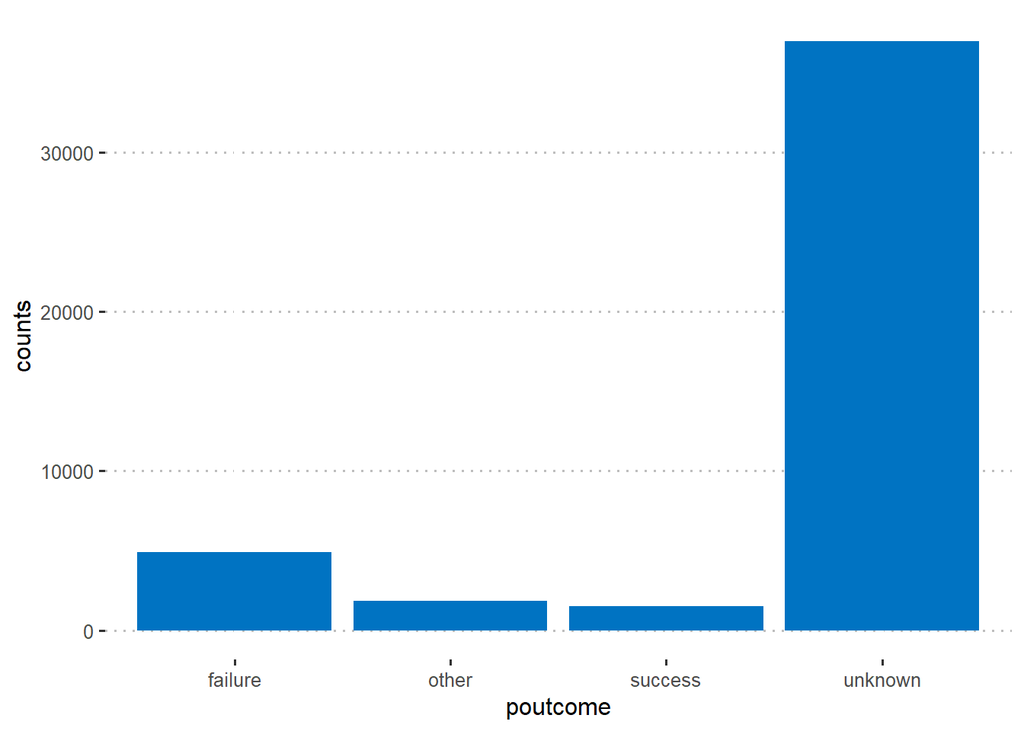

```r
poutcome.groups <- bank.other.y %>% group_by(poutcome) %>% summarise(counts = n())
ggplot(poutcome.groups, aes(x = poutcome, y = counts)) + geom_bar(fill = "#0073C2FF", stat = "identity")  + theme_pubclean()
```

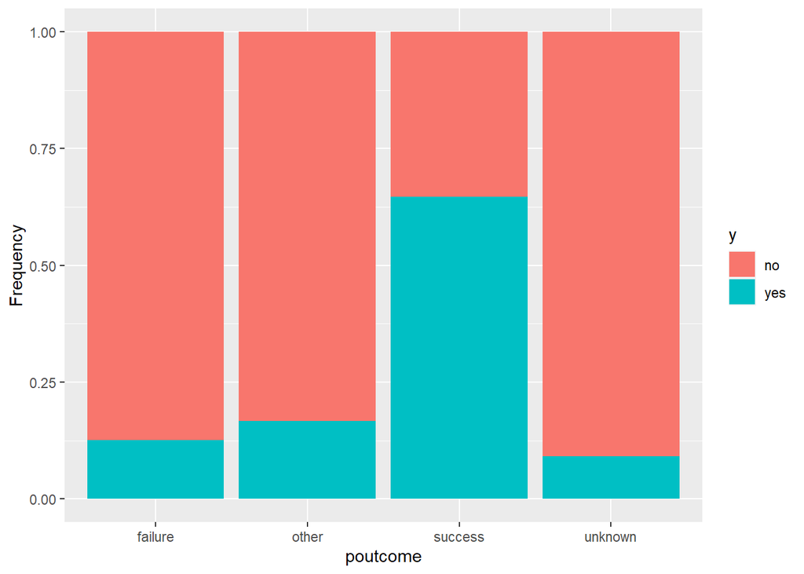

```r
ggplot(data=bank.other.y,aes(x=poutcome,fill=y)) + geom_bar(position="fill") + ylab("Frequency")
```

Clarament si van contractar prèviament, sembla que repeteixen. Aquesta dada és un molt bon target.

- Amb aquest estudi visual ens hem fet la idea que converteix o afecta més i les distribucions, però a la pràctica 2:
1. Amb l’estudi de classificació podrem predir si un nou registre amb unes dades convertirà o no. Introduïm unes dades d’un usuari exemple i hem de veure si és un “yes” o “no” en la variable “y”.
2. Aplicarem regles d’associació per veure quins atributs combinats donen -> y = ‘yes’ o y = ‘no’
3. Si apliquem clustering podrem veure tipologia de clients.

## 3.3 Tasques de neteja

### 3.3.1 Camps null (missing values)

Com hem comentat ja durant tot l’exercici, la mostra no té valors nulls com a tals.

```r
colSums(is.na(bank))
```

```
##       age       job   marital education   default   balance   housing      loan
##         0         0         0         0         0         0         0         0
##   contact       day     month  duration  campaign     pdays  previous  poutcome
##         0         0         0         0         0         0         0         0
##         y
##         0
```

El que sí que té en els elements categòrics són camps ‘unknown’.

Tenim 3 opcions per aquests valors:

1. Eliminar els registres
2. Assignar per un valor estimat
3. **No fer res i tractar-los com a una categoria.** És l’opció que prefereixo.

Optarem per la solució 3 per aquests motius:

- Els valors ‘unknown’ poden representar per si mateix una categoria única.
- Pot haver-hi una diferència important de dades si eliminem els ‘unknown’
- Tot el que ha causat el camp ‘unknown’ pot estar relacionat amb el resultat.

De totes maneres anem a estudiar aquests elements i generarem un dataset diferent:

```r
#creem el dataset per les dades netejades
bank.clean <- bank
```

Anem a comprovar els percentatges de unknown

```r
# valors 'unknown' de job
{
print("Job")
print(prop.table(table(bank$job)), 2)
}
```

```
## [1] "Job"
##
##        admin.   blue-collar  entrepreneur     housemaid    management
##        0.1144        0.2153        0.0329        0.0274        0.2092
##       retired self-employed      services       student    technician
##        0.0501        0.0349        0.0919        0.0207        0.1680
##    unemployed       unknown
##        0.0288        0.0064
```

```r
# valors 'unknown' de education
{
cat('\n')
print('Education:')
print(prop.table(table(bank$education)), 2)
}
```

```
##
## [1] "Education:"
##
##   primary secondary  tertiary   unknown
##     0.152     0.513     0.294     0.041
```

```r
# valors 'unknown' de contact
{
cat('\n')
print('Contact:')
print(prop.table(table(bank$contact)), 2)
}
```

```
##
## [1] "Contact:"
##
##  cellular telephone   unknown
##     0.648     0.064     0.288
```

```r
# valors 'unknown' de poutcome
{
cat('\n')
print('Poutcome:')
print(prop.table(table(bank$poutcome)), 2)
}
```

```
##
## [1] "Poutcome:"
##
## failure   other success unknown
##   0.108   0.041   0.033   0.817
```

Com podem observar podem eliminar els ‘unknown’ de job i education perquè la proporció és petita, en canvi, amb contact i poutcome podríem fer una assignació estimada, ja que tenim quasi un 30% en contact i més d’un 80% en poutcome.

```r
# eliminem els unknown de job i de education
total.rows <- nrow(bank.clean);
bank.clean <-subset(bank.clean, education != "unknown")
bank.clean <- subset(bank.clean, job != "unknown")

# eliminem categories buides
bank.clean <- droplevels(bank.clean)

rows <- nrow(bank.clean);
(rows / total.rows) * 100
```

```
## [1] 95.53648
```

Eliminant els unknown de education i job encara tindríem més del 95.5% de la mostra.

### 3.3.2 Valors atípics extrems (outliers)

Ara anem a veure els valors atípics. Per a trobar valors extrems anem a aplicar la idea dels IQR (interquartile ranges): * [referència1:](http://www.mathwords.com/o/outlier.htm) * [referència2:](http://r-statistics.co/Outlier-Treatment-With-R.html)

Per a una determinada variable contínua, els outliers són aquelles observacions que es troben fora de 1.5 * IQR, on IQR, el “Inter Quartile Range” és la diferència entre el Q3 i el Q1:

- Interquartile range, IQR = Q3 - Q1
- lower = Q1 - 1.5 * IQR
- Upper = Q3 + 1.5 * IQR

### 3.3.3 Funció per treure els límits dels valors atípics

```r
outliersLimits <- function(x) {
    limits <- c("above", "under")
    limits$above <- quantile(x, 0.75, type=6) + 1.5 * (quantile(x, 0.75, type=6) - quantile(x, 0.25, type=6))
    limits$under <- quantile(x, 0.25, type=6) - 1.5 * (quantile(x, 0.75, type=6) - quantile(x, 0.25, type=6))
  return(limits)
}
```

### 3.3.4 Valors atípics a age

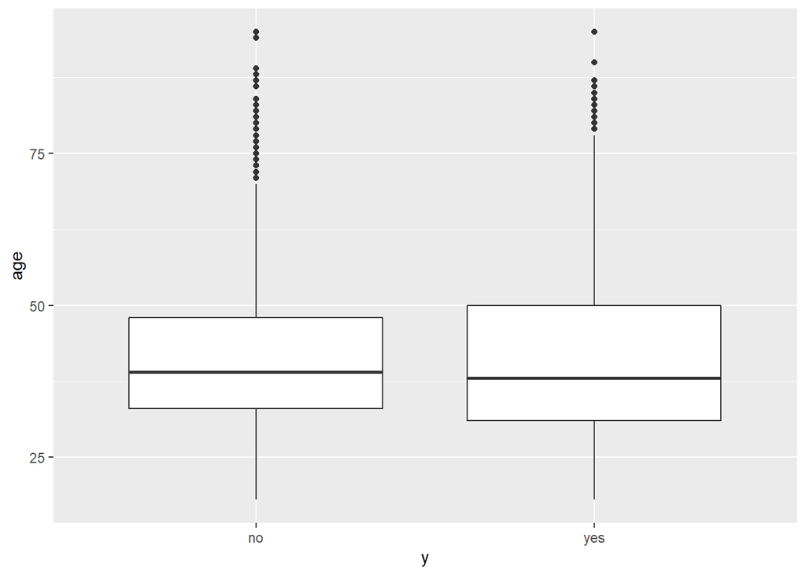

```r
ggplot(data = bank.clean ,aes(x=y,y=age))+geom_boxplot()
```

```r
# podem veure els límits de age
limits <- outliersLimits(bank.clean$age)
paste("Límit inferior:", limits$under)
```

```
## [1] "Límit inferior: 10.5"
```

```r
paste("Límit superior:", limits$above)
```

```
## [1] "Límit superior: 70.5"
```

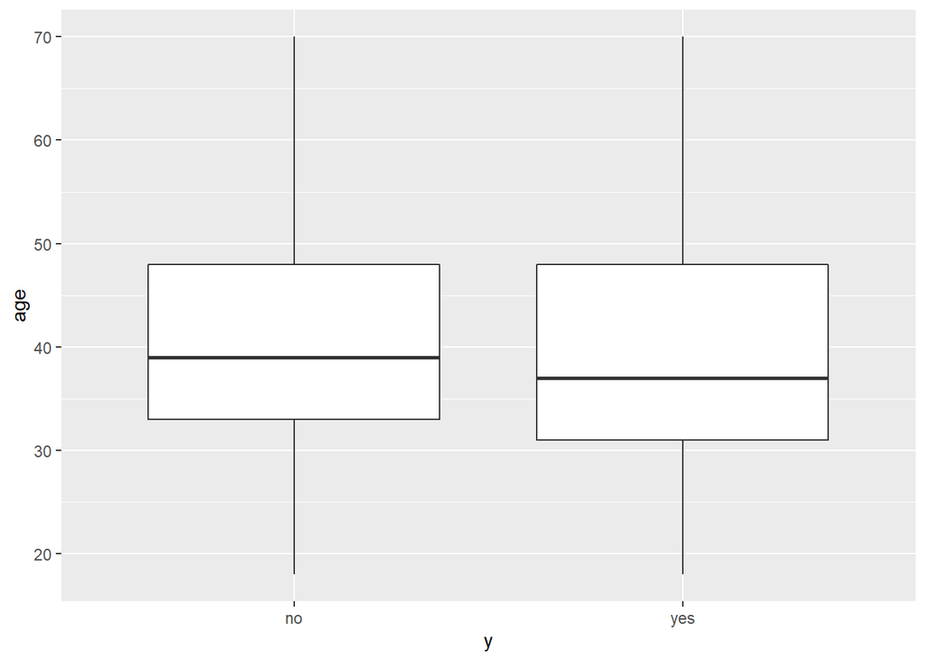

```r
# treiem aquest valors atípics
bank.clean <-subset(bank.clean, age >= limits$under)
bank.clean <-subset(bank.clean, age <= limits$above)

ggplot(data = bank.clean,aes(x=y,y=age))+geom_boxplot()
```

```r
total.rows <- nrow(bank.clean);
rows <- nrow(bank.clean)
(rows / total.rows) * 100
```

```
## [1] 100
```

Amb boxplot podem preveure alguns valors d’edat que tenen molt poca mostra i no ens donarien molta informació.

### 3.3.5 El mateix per a balance

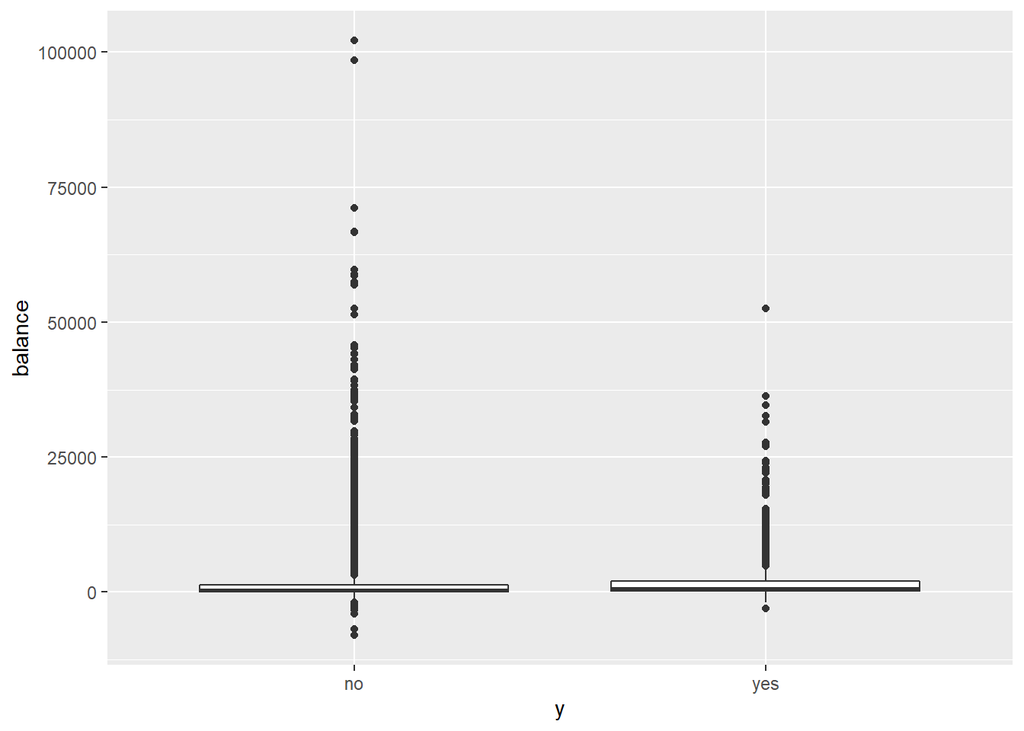

```r
ggplot(data = bank.clean ,aes(x=y,y=balance))+geom_boxplot()
```

```r
total.rows <- nrow(bank.clean);

# podem veure els límits de balance
limits <- outliersLimits(bank.clean$balance)
paste("Límit inferior:", limits$under)
```

```
## [1] "Límit inferior: -1923"
```

```r
paste("Límit superior:", limits$above)
```

```
## [1] "Límit superior: 3389"
```

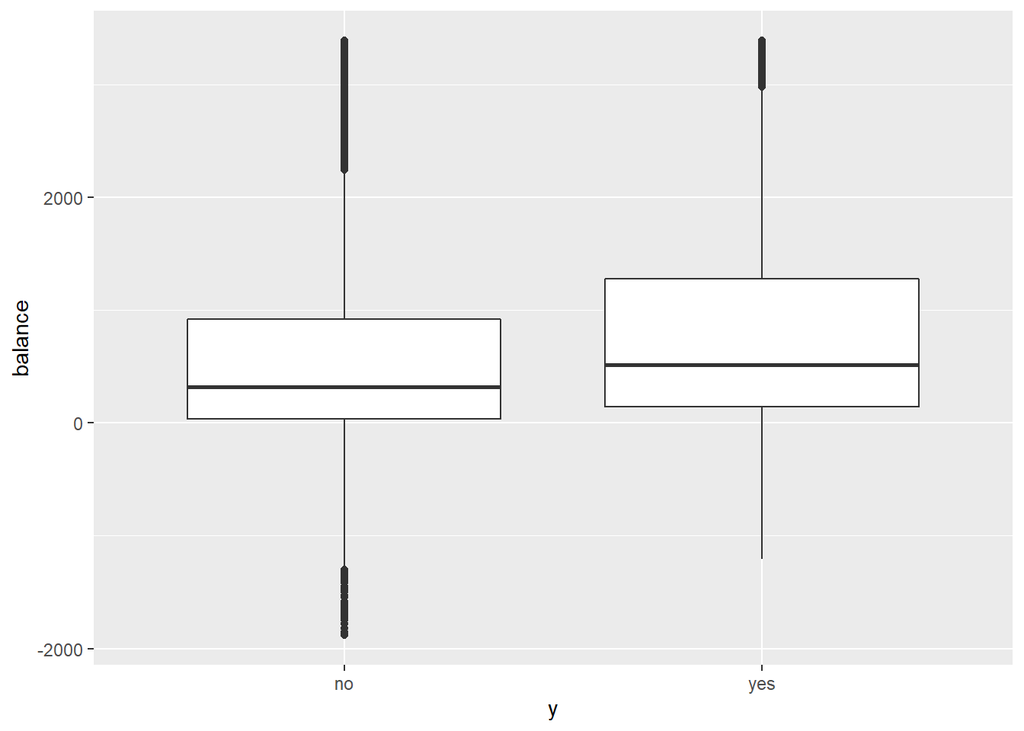

```r
# treiem aquest valors atípics
bank.clean <-subset(bank.clean, balance >= limits$under)
bank.clean <-subset(bank.clean, balance <= limits$above)

ggplot(data = bank.clean,aes(x=y,y=balance))+geom_boxplot()
```

```r
rows <- nrow(bank.clean)
(rows / total.rows) * 100
```

```
## [1] 89.46187
```

Les mostres queden molt més compactades eliminant aquests valors extrems.

```r
total.rows <- nrow(bank);
rows <- nrow(bank.clean);
(rows / total.rows) * 100
```

```
## [1] 84.60994
```

Finalment hem calculat el quin percentatge de la mostra hem eliminat amb els valors atípics i el ‘unkwown’ i ens ha quedat un 84.61% del total.

Treballarem amb els dos models per a comparar-los: 1. bank (original) 2. bank.clean (hem tret alguns unknown i valors atípics)

## 3.4 Discretització

Anem a discretitzar algunes variables continues que ens serviran per a reduir el factor de ramificació quan realitzem la classificació amb els arbres de decisió.

### 3.4.1 Discretització de la variable age

```r
# creem els dos datasets amb l'original i el clean (sense 'unknown' i 'outliers')
bank.discret <- bank
bank.clean.discret <- bank.clean
```

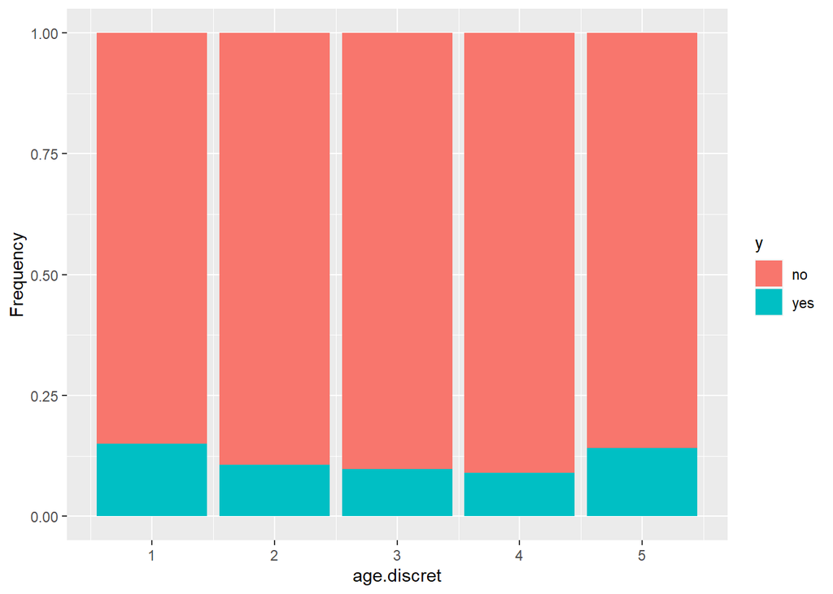

```r
# dicretitzem el dataset bank
age.discret <- discretize(bank$age, breaks = 5, labels=FALSE)
bank.discret$age <- age.discret


## observem com queda la distribució i comparem amb la conversió
ggplot(data=bank.discret,aes(x=age.discret,fill=y)) + geom_bar(position="fill") + ylab("Frequency")
```

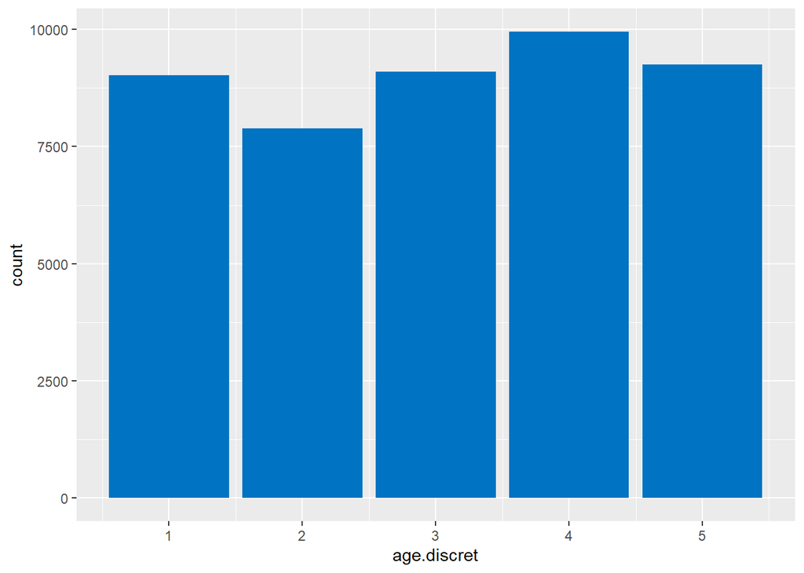

```r
ggplot(bank.discret, aes(age.discret)) + geom_bar(fill = "#0073C2FF")
```

```r
# dicretitzem el dataset bank.clean
bank.clean.discret$age <- discretize(bank.clean$age, breaks = 5, labels=FALSE)
```

### 3.4.2 Discretització de la variable duration

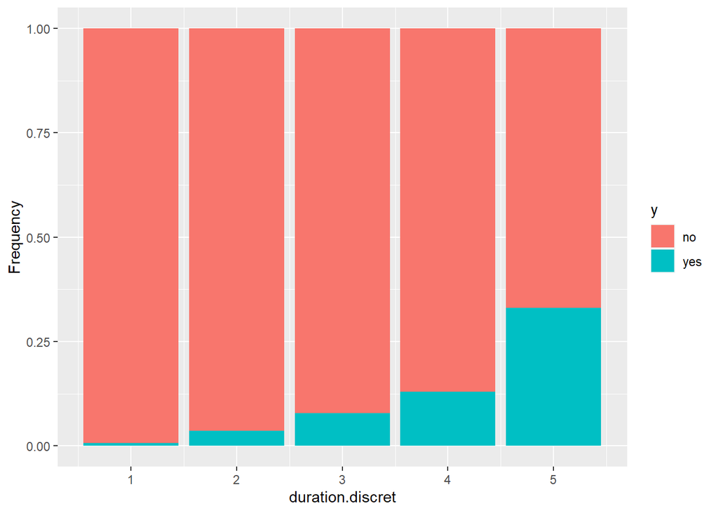

```r
# dicretitzem el dataset bank
duration.discret <- discretize(bank$duration, breaks = 5, labels=FALSE)
bank.discret$duration <- duration.discret

## observem com queda la distribució i comparem amb la conversió
ggplot(data=bank.discret,aes(x=duration.discret,fill=y)) + geom_bar(position="fill") + ylab("Frequency")
```

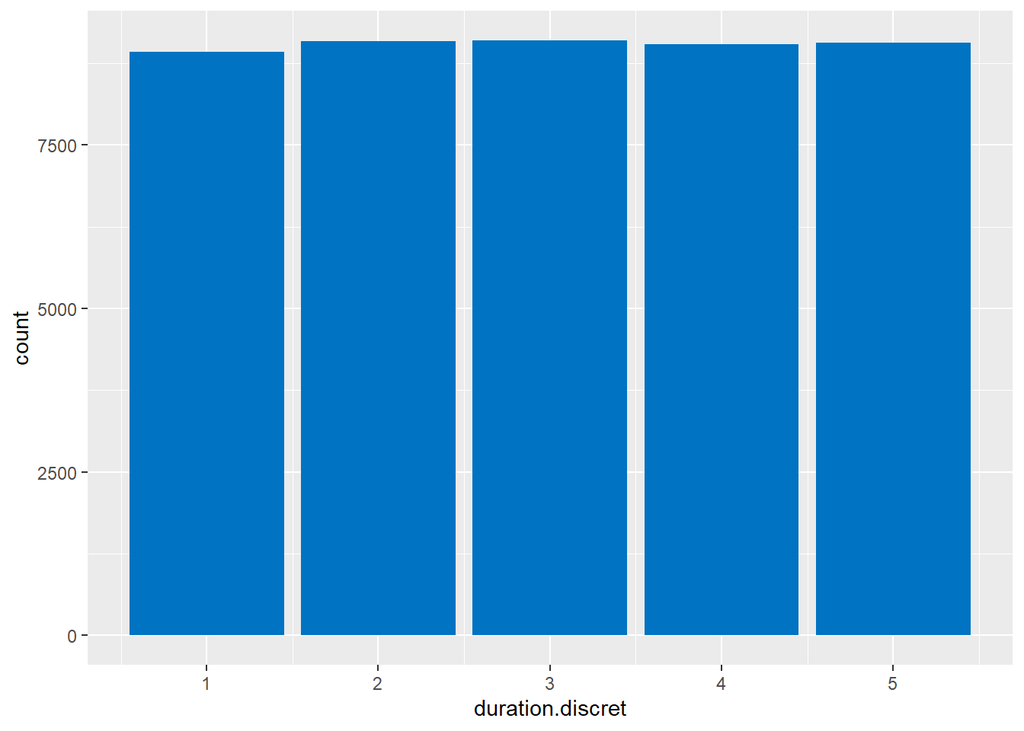

```r
ggplot(bank.discret, aes(duration.discret)) + geom_bar(fill = "#0073C2FF")
```

```r
# dicretitzem el dataset bank.clean
bank.clean.discret$duration <- discretize(bank.clean$duration, breaks = 5, labels=FALSE)
```

Finalment ens han quedat 2 datasets:

- bank.discret: on només hem aplicat discretització en dues variables
- bank.clean.discret: on hem aplicat discretització, eliminat outliers i alguns ‘unknown’, concretament aquells que no tenien molta proporció.

## 3.5 Estudi PCA (Principal Component Analysis)

En l’estudi de PCA el que es vol es trobar un nombre de dimensions menor de la mostra que expliquin el mateix que la mostra total. A nivell matemàtic funciona amb el concepte de ‘eigenvectors’ i ‘eigenvalues’, que són valors que simplifiquen una matriu dient el mateix que la matriu original: [Eigenvector and Eigenvalue](https://www.mathsisfun.com/algebra/eigenvalue.html)

El que fem és trobar la variànça total del conjunt de dades i intentarem reduir la dimensionalitat mantenint aquesta varinça al màxim. Per exemple, si tinguesim amb 10 dimensions un > 95% de la variança ja ens donariem per satisfets. L’elecció es realitza de manera que la primera component principal sigui la que major variància reculli; la segona ha de recollir la màxima variabilitat no recollida per la primera, i així successivament, triant un nombre que reculli un percentatge suficient de variància total.

Dividirem l’estudi en les dades quantitatives (PCA, Principal Component Analysis) i mixed (FAMD, Factor Analysis of Mixed Data) per a dades qualitatives i quantitatives. [Info](https://rpkgs.datanovia.com/factoextra/)

### 3.5.1 Dades quantitatives (PCA)

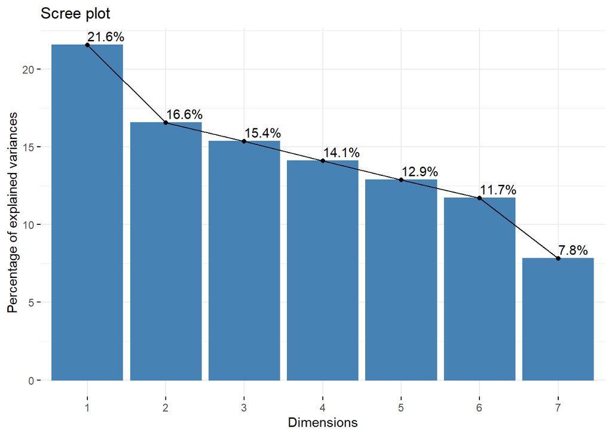

```r
bank.pca <- bank.clean
quantitative <-  bank.pca[,c(1,6,10,12:15)]

# executem l'estudi PCA
pca <- prcomp(quantitative, scale. = TRUE)

# la funció mostra la variança de cada component
fviz_eig(pca, choice = c("variance"), addlabels = TRUE)
```

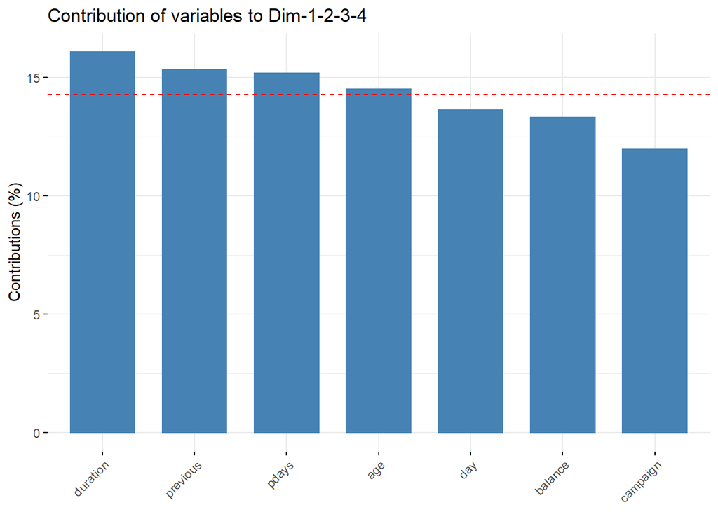

```r
# relació entre les dimensions i atributs.
fviz_contrib(pca, choice = "var", axes = 1:4)
```

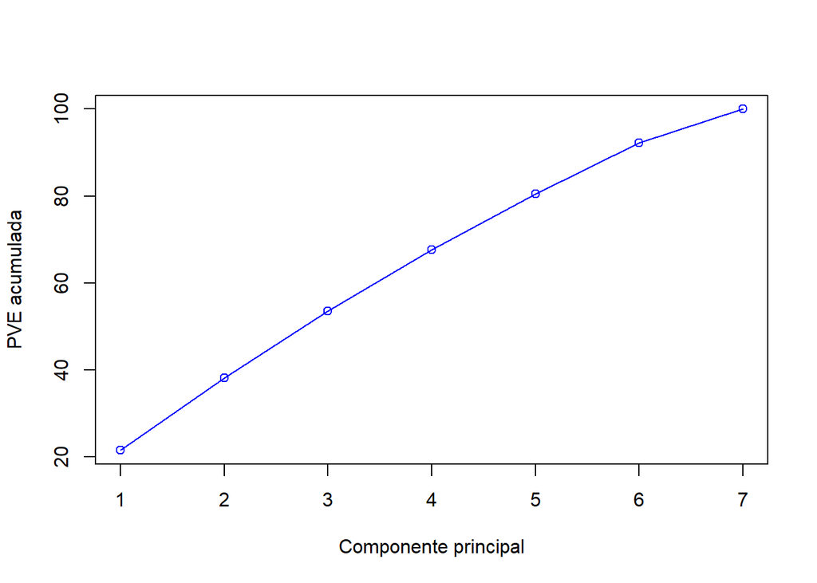

```r
# pve acumulada
PVE <- 100*pca$sdev^2/sum(pca$sdev^2)

plot(cumsum(PVE), type = "o",
     ylab = "PVE acumulada",
     xlab = "Componente principal",
     col = "blue")
```

### 3.5.2 Dades mixtes (FAMD)

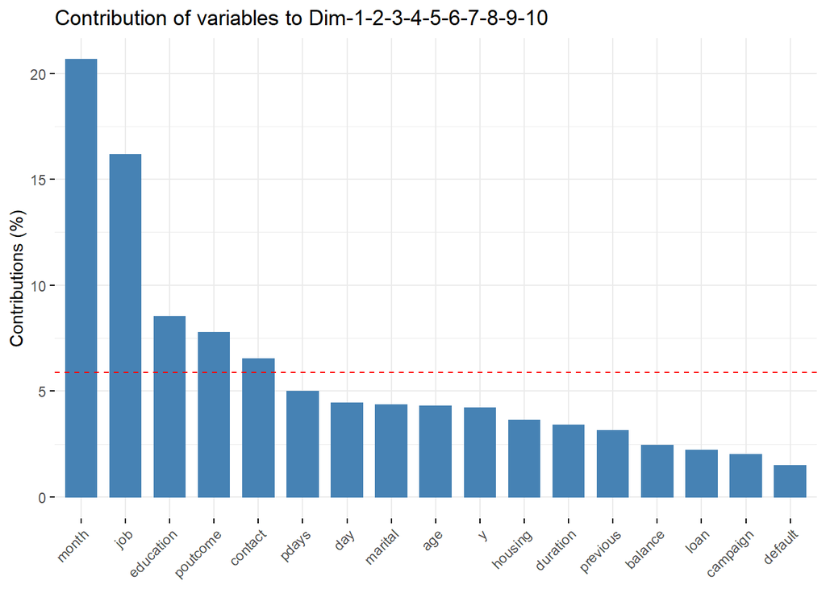

```r
mixed <- bank.clean

res.famd <- FAMD(mixed, graph = FALSE, ncp = 17)

# relació entre les dimensions i atributs.
fviz_contrib(res.famd, choice = "var", axes = 1:10)
```

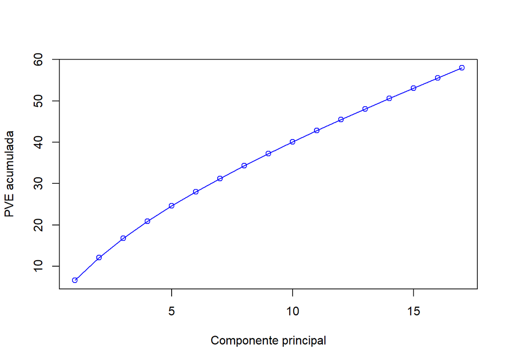

```r
plot(res.famd$eig[,3], type = "o",
     ylab = "PVE acumulada",
     xlab = "Componente principal",
     col = "blue")
```

Ara hem fet estudi amb tota la mostra, dades qualitatives i quantitatives. Com era de preveure la dada que menys aporta a les 10 principals dimensions i que **segurament podem eliminar es default**. Hem vist que la majoria de la mostra d’aquest atribut és d’un únic element.

# 4 Clustering

## 4.1 Joc de dades

L’estudi de clustering el farem amb un dataset de [venta online](http://archive.ics.uci.edu/ml/datasets/Online+Retail).

Aquest és un conjunt de dades que conté totes les transaccions que es realitzen entre el 01/12/2010 i el 09/12/2011 per a un comerç online registrat al Regne Unit. La companyia ven sobretot regals únics per a totes les ocasions. Molts clients de l’empresa són majoristes. Tenim alguna informació bàsica (InvoiceNo, StockCode, Description, Quantity,…).

- Amb aquest estudi pretenem trobar clusters agrupant tipus de clients o tipus de productes.
- També farem servir aquest dataset per executar l’algoritme d’associació i veure quines tendencies de compra tenen els usuaris. Relacions entre els productes comprats.

## 4.2 Anàlisi exploratori

```r
retail <- read.csv('data/online-retail/data.csv',stringsAsFactors = TRUE, sep = ',')
attach(retail)
```

### 4.2.1 Definició dels atributs

- 1 - InvoiceNo: Número de factura. Un número enter de 6 dígits assignat exclusivament a cada transacció. Si aquest codi comença amb la lletra ‘c’ indica una cancel·lació. Character
- 2 - StockCode: codi de producte (producte). Un string de 5 dígits assignat exclusivament a cada producte diferent. Character
- 3 - Description: Nom del producte (article). Character
- 4 - Quantity: les quantitats de cada producte (article) per transacció. Numeric
- 5 - InvoiceDate: data i hora de la factura. El dia i l’hora en què es va generar la transacció. Numèric.
- 6 - UnitPrice: Preu unitari. Preu del producte per unitat en lliure esterlina (£). Numèric.
- 7 - CustomerID: Un 5 dígits assignat exclusivament a cada client. Character
- 8 - Country: nom del país. El nom del país on resideix un client. Character

```r
summary(retail)
```

```
##    InvoiceNo        StockCode                                  Description
##  573585 :  1114   85123A :  2313   WHITE HANGING HEART T-LIGHT HOLDER:  2369
##  581219 :   749   22423  :  2203   REGENCY CAKESTAND 3 TIER          :  2200
##  581492 :   731   85099B :  2159   JUMBO BAG RED RETROSPOT           :  2159
##  580729 :   721   47566  :  1727   PARTY BUNTING                     :  1727
##  558475 :   705   20725  :  1639   LUNCH BAG RED RETROSPOT           :  1638
##  579777 :   687   84879  :  1502   ASSORTED COLOUR BIRD ORNAMENT     :  1501
##  (Other):537202   (Other):530366   (Other)                           :530315
##     Quantity                   InvoiceDate       UnitPrice
##  Min.   :-80995.00   10/31/2011 14:41:  1114   Min.   :-11062.06
##  1st Qu.:     1.00   12/8/2011 9:28  :   749   1st Qu.:     1.25
##  Median :     3.00   12/9/2011 10:03 :   731   Median :     2.08
##  Mean   :     9.55   12/5/2011 17:24 :   721   Mean   :     4.61
##  3rd Qu.:    10.00   6/29/2011 15:58 :   705   3rd Qu.:     4.13
##  Max.   : 80995.00   11/30/2011 15:13:   687   Max.   : 38970.00
##                      (Other)         :537202
##    CustomerID               Country
##  Min.   :12346    United Kingdom:495478
##  1st Qu.:13953    Germany       :  9495
##  Median :15152    France        :  8557
##  Mean   :15288    EIRE          :  8196
##  3rd Qu.:16791    Spain         :  2533
##  Max.   :18287    Netherlands   :  2371
##  NA's   :135080   (Other)       : 15279
```

### 4.2.2 Analisi de les dades dels clients

Anem a veure com estan distribuïts els diferents atributs del dataset.

### 4.2.3 Invoices x paísos

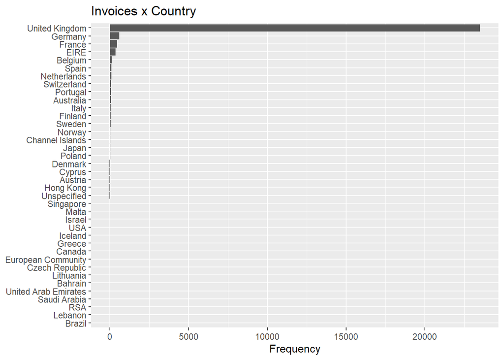

```r
invoices.country <- retail %>% group_by(Country) %>% summarise(NumInvoices = n_distinct(InvoiceNo))
ggplot(invoices.country, aes(x = reorder(Country, NumInvoices), y = NumInvoices)) +
    geom_col() +
    labs(title="Invoices x Country ",
         x = NULL,
         y = "Frequency") +
    coord_flip()
```

Veiem clarament que la majoria de comandes vénen del Regne Unit molt de lluny seguit d’Alemania i França. La botiga online està registrada a Regne Unit.

### 4.2.4 Tipologia de productes (Description)

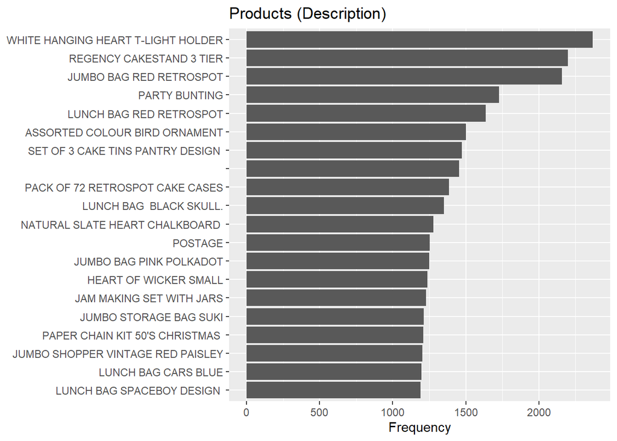

```r
ndescriptions <- groups(retail, 'Description')
ndescriptions <- ndescriptions[order(ndescriptions$freq, decreasing = TRUE), ]
ndescriptions <- ndescriptions[1:20, ]

ggplot(ndescriptions, aes(x = reorder(Description, counts), y = counts)) +
    geom_col() +
    labs(title="Products (Description) ",
         x = NULL,
         y = "Frequency") +
    coord_flip()
```

Els 20 productes que més apareixen a la mostra. Veiem un producte que no té Description. Li afegim una.

```r
ndescription <- subset(retail, Description == '')
head(ndescriptions)
```

```
## # A tibble: 6 x 3
##   Description                        counts  freq
##   <fct>                               <int> <dbl>
## 1 WHITE HANGING HEART T-LIGHT HOLDER   2369 0.437
## 2 REGENCY CAKESTAND 3 TIER             2200 0.406
## 3 JUMBO BAG RED RETROSPOT              2159 0.398
## 4 PARTY BUNTING                        1727 0.319
## 5 LUNCH BAG RED RETROSPOT              1638 0.302
## 6 ASSORTED COLOUR BIRD ORNAMENT        1501 0.277
```

Donant una ullada veig que són valors rars que tenen CustomerId amb null. Aquests valors els esborrarem.

### 4.2.5 Densitat de UnitPrice

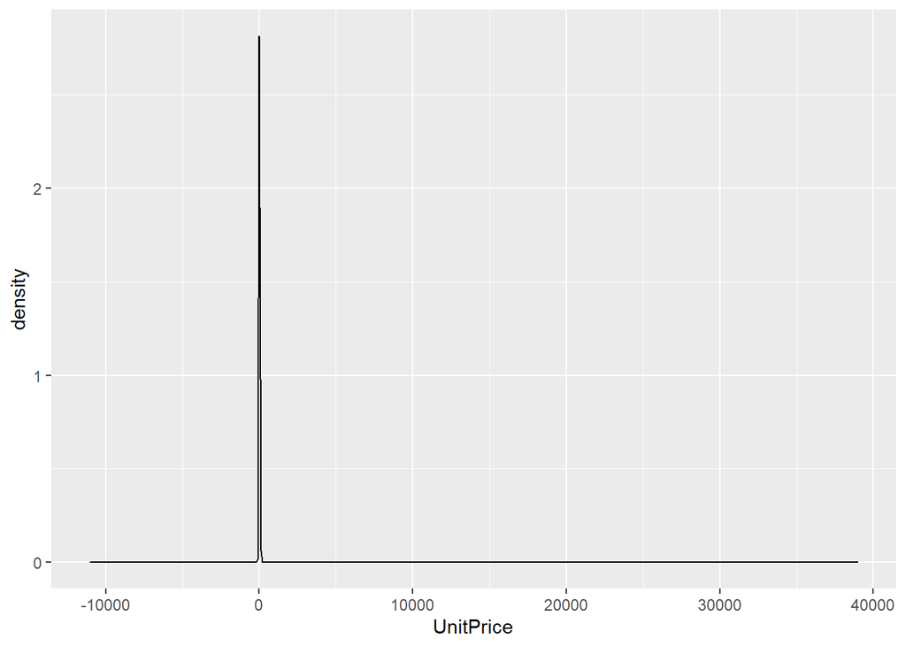

```r
ggplot(retail, aes(x = UnitPrice))+ geom_density()
```

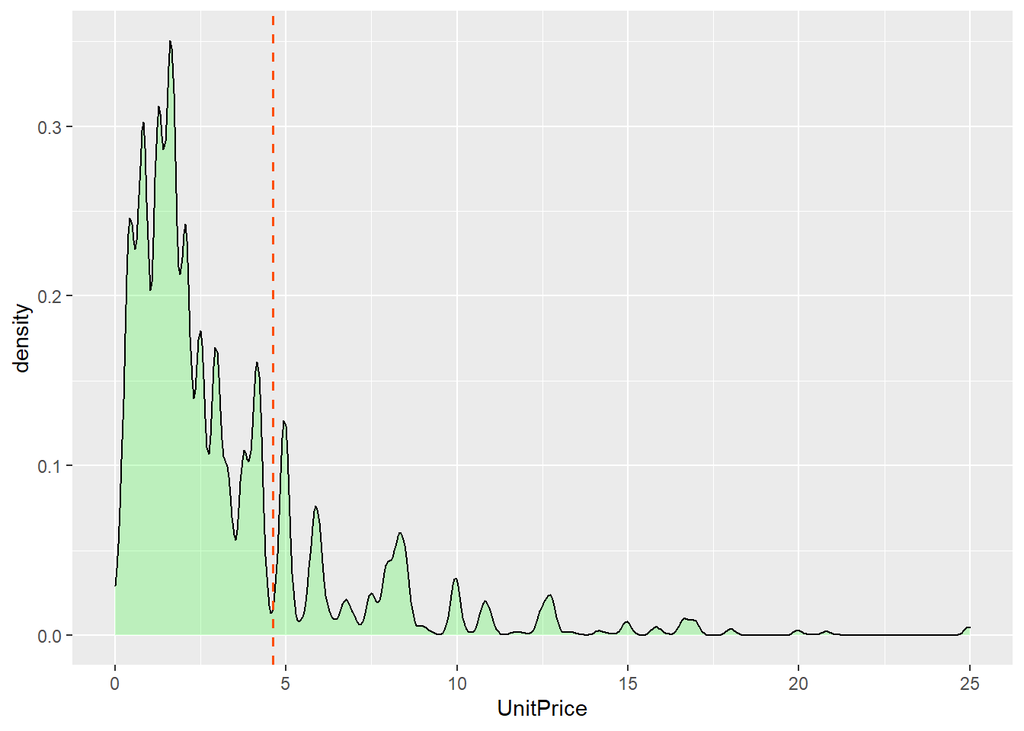

```r
ggplot(retail, aes(x = UnitPrice))+ geom_density(fill = "green", alpha = 0.2) + geom_vline(aes(xintercept = mean(UnitPrice)),
             linetype = "dashed", size = 0.6,
             color = "#FC4E07") + xlim(c(0, 25))
```

Aquesta gràfica ens diu que la majoria de preus de productes tenen valors petits. Amb el summary ja es veia ja que (1st Qu.:1.25, Median :2.08, Mean: 4.61, 3rd Qu.: 4.13). Entre 1 i 4 lliures es mouen la majoria de preus, encara que hi ha valors extrems. Els valors negatius són devolucions.

En la segona gràfica, he limitat el marge de preus. La línia vermella mostra la mitja.

### 4.2.6 Densitat de Quantity

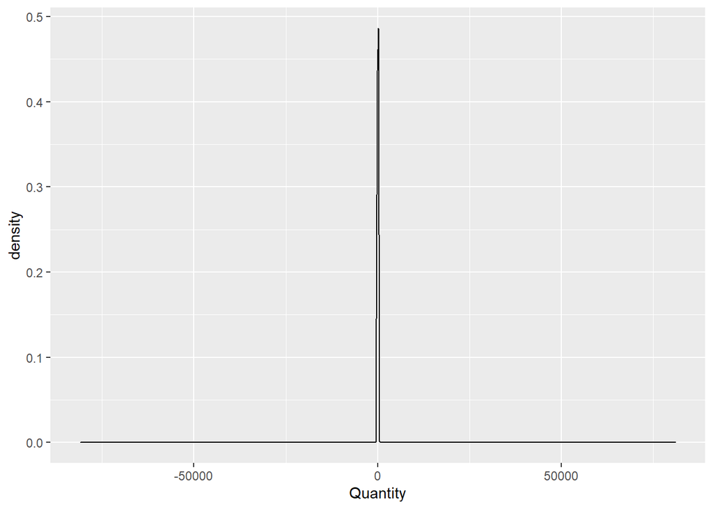

```r
ggplot(retail, aes(x = Quantity))+ geom_density()
```

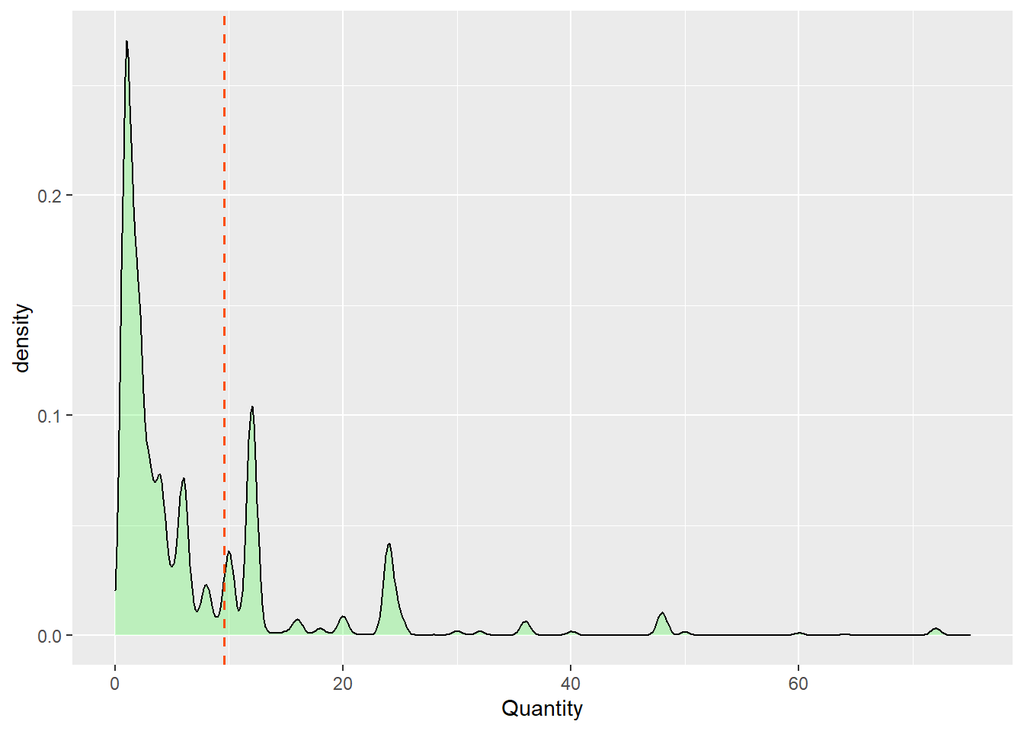

```r
ggplot(retail, aes(x = Quantity))+ geom_density(fill = "green", alpha = 0.2) + geom_vline(aes(xintercept = mean(Quantity)),
             linetype = "dashed", size = 0.6,
             color = "#FC4E07") + xlim(c(0, 75))
```

El mateix estudi per a Quantity. Passa molt similar. Veiem que tenim extrems atípics però la desviació és molt petita. Els negatius són les devolucions.

## 4.3 Crear nous atributs

Crearem atributs nous per a tot el dataset

### 4.3.1 Returned

Valor boolean que ens indica que si és una cancel·lació.

```r
retail$Cancellation <- startsWith(as.character(retail$InvoiceNo), 'C')
cancellations <- subset(retail, retail$Cancellation  == 'TRUE')
head(cancellations)
```

```
##     InvoiceNo StockCode                       Description Quantity
## 142   C536379         D                          Discount       -1
## 155   C536383    35004C   SET OF 3 COLOURED  FLYING DUCKS       -1
## 236   C536391     22556    PLASTERS IN TIN CIRCUS PARADE       -12
## 237   C536391     21984  PACK OF 12 PINK PAISLEY TISSUES       -24
## 238   C536391     21983  PACK OF 12 BLUE PAISLEY TISSUES       -24
## 239   C536391     21980 PACK OF 12 RED RETROSPOT TISSUES       -24
##         InvoiceDate UnitPrice CustomerID        Country Cancellation
## 142  12/1/2010 9:41     27.50      14527 United Kingdom         TRUE
## 155  12/1/2010 9:49      4.65      15311 United Kingdom         TRUE
## 236 12/1/2010 10:24      1.65      17548 United Kingdom         TRUE
## 237 12/1/2010 10:24      0.29      17548 United Kingdom         TRUE
## 238 12/1/2010 10:24      0.29      17548 United Kingdom         TRUE
## 239 12/1/2010 10:24      0.29      17548 United Kingdom         TRUE
```

```r
paste("Percetatge de cancel·lacions: ", round(nrow(cancellations) / nrow(retail) * 100,3))
```

```
## [1] "Percetatge de cancel·lacions:  1.714"
```

### 4.3.2 TotalPrice

Càlcul del preu total del registre (Quantity * UnitPrice)

```r
retail$TotalPrice <- retail$Quantity * retail$UnitPrice
head(retail)
```

```
##   InvoiceNo StockCode                         Description Quantity
## 1    536365    85123A  WHITE HANGING HEART T-LIGHT HOLDER        6
## 2    536365     71053                 WHITE METAL LANTERN        6
## 3    536365    84406B      CREAM CUPID HEARTS COAT HANGER        8
## 4    536365    84029G KNITTED UNION FLAG HOT WATER BOTTLE        6
## 5    536365    84029E      RED WOOLLY HOTTIE WHITE HEART.        6
## 6    536365     22752        SET 7 BABUSHKA NESTING BOXES        2
##      InvoiceDate UnitPrice CustomerID        Country Cancellation TotalPrice
## 1 12/1/2010 8:26      2.55      17850 United Kingdom        FALSE      15.30
## 2 12/1/2010 8:26      3.39      17850 United Kingdom        FALSE      20.34
## 3 12/1/2010 8:26      2.75      17850 United Kingdom        FALSE      22.00
## 4 12/1/2010 8:26      3.39      17850 United Kingdom        FALSE      20.34
## 5 12/1/2010 8:26      3.39      17850 United Kingdom        FALSE      20.34
## 6 12/1/2010 8:26      7.65      17850 United Kingdom        FALSE      15.30
```

## 4.4 Tasques de neteja

### 4.4.1 Camps null (missing values)

Eliminem els valors nulls de CustomerID, ja que molts tenen registres bruts.

```r
retail.clean <- retail
total.num <- nrow(retail)
retail.clean <- subset(retail.clean, !is.na(CustomerID))
cat("Hem eliminat un:", 100 - round(nrow(retail.clean) / total.num * 100, 2), "de registres.")
```

```
## Hem eliminat un: 24.93 de registres.
```

### 4.4.2 Valors atípics extrems (outliers)

Ja hem netejat força la mostra però si tenim més valors atípics.

```r
summary(retail.clean)
```

```
##    InvoiceNo        StockCode                                  Description
##  576339 :   542   85123A :  2077   WHITE HANGING HEART T-LIGHT HOLDER:  2070
##  579196 :   533   22423  :  1905   REGENCY CAKESTAND 3 TIER          :  1905
##  580727 :   529   85099B :  1662   JUMBO BAG RED RETROSPOT           :  1662
##  578270 :   442   84879  :  1418   ASSORTED COLOUR BIRD ORNAMENT     :  1418
##  573576 :   435   47566  :  1416   PARTY BUNTING                     :  1416
##  567656 :   421   20725  :  1359   LUNCH BAG RED RETROSPOT           :  1358
##  (Other):403927   (Other):396992   (Other)                           :397000
##     Quantity                   InvoiceDate       UnitPrice
##  Min.   :-80995.00   11/14/2011 15:27:   543   Min.   :    0.00
##  1st Qu.:     2.00   11/28/2011 15:54:   534   1st Qu.:    1.25
##  Median :     5.00   12/5/2011 17:17 :   530   Median :    1.95
##  Mean   :    12.06   11/23/2011 13:39:   444   Mean   :    3.46
##  3rd Qu.:    12.00   10/31/2011 14:09:   436   3rd Qu.:    3.75
##  Max.   : 80995.00   9/21/2011 14:40 :   422   Max.   :38970.00
##                      (Other)         :403920
##    CustomerID              Country       Cancellation      TotalPrice
##  Min.   :12346   United Kingdom:361878   Mode :logical   Min.   :-168469.6
##  1st Qu.:13953   Germany       :  9495   FALSE:397924    1st Qu.:      4.2
##  Median :15152   France        :  8491   TRUE :8905      Median :     11.1
##  Mean   :15288   EIRE          :  7485                   Mean   :     20.4
##  3rd Qu.:16791   Spain         :  2533                   3rd Qu.:     19.5
##  Max.   :18287   Netherlands   :  2371                   Max.   : 168469.6
##                  (Other)       : 14576
```

### 4.4.3 Valors atípics a Quantity

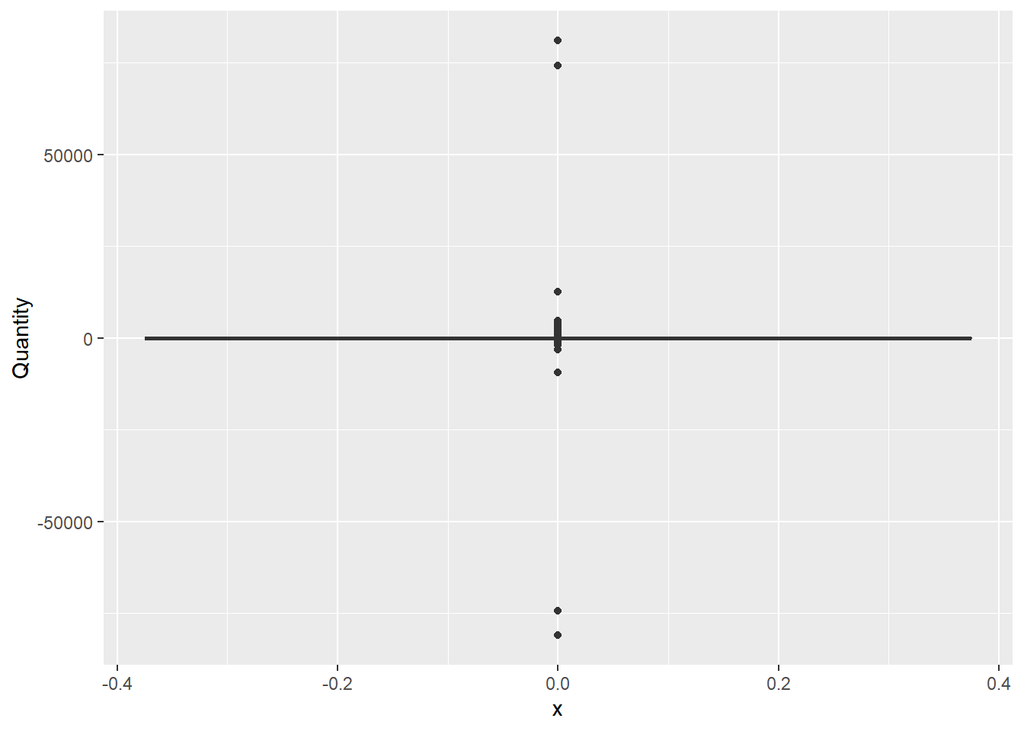

```r
retail.quantity.nooutliers <- retail.clean

ggplot(data = retail.quantity.nooutliers ,aes(x=0,y=Quantity))+geom_boxplot()
```

```r
summary(retail.quantity.nooutliers)
```

```
##    InvoiceNo        StockCode                                  Description
##  576339 :   542   85123A :  2077   WHITE HANGING HEART T-LIGHT HOLDER:  2070
##  579196 :   533   22423  :  1905   REGENCY CAKESTAND 3 TIER          :  1905
##  580727 :   529   85099B :  1662   JUMBO BAG RED RETROSPOT           :  1662
##  578270 :   442   84879  :  1418   ASSORTED COLOUR BIRD ORNAMENT     :  1418
##  573576 :   435   47566  :  1416   PARTY BUNTING                     :  1416
##  567656 :   421   20725  :  1359   LUNCH BAG RED RETROSPOT           :  1358
##  (Other):403927   (Other):396992   (Other)                           :397000
##     Quantity                   InvoiceDate       UnitPrice
##  Min.   :-80995.00   11/14/2011 15:27:   543   Min.   :    0.00
##  1st Qu.:     2.00   11/28/2011 15:54:   534   1st Qu.:    1.25
##  Median :     5.00   12/5/2011 17:17 :   530   Median :    1.95
##  Mean   :    12.06   11/23/2011 13:39:   444   Mean   :    3.46
##  3rd Qu.:    12.00   10/31/2011 14:09:   436   3rd Qu.:    3.75
##  Max.   : 80995.00   9/21/2011 14:40 :   422   Max.   :38970.00
##                      (Other)         :403920
##    CustomerID              Country       Cancellation      TotalPrice
##  Min.   :12346   United Kingdom:361878   Mode :logical   Min.   :-168469.6
##  1st Qu.:13953   Germany       :  9495   FALSE:397924    1st Qu.:      4.2
##  Median :15152   France        :  8491   TRUE :8905      Median :     11.1
##  Mean   :15288   EIRE          :  7485                   Mean   :     20.4
##  3rd Qu.:16791   Spain         :  2533                   3rd Qu.:     19.5
##  Max.   :18287   Netherlands   :  2371                   Max.   : 168469.6
##                  (Other)       : 14576
```

```r
# podem veure els límits de Quantity
limits <- outliersLimits(retail.quantity.nooutliers$Quantity)
paste("Límit inferior:", limits$under)
```

```
## [1] "Límit inferior: -13"
```

```r
paste("Límit superior:", limits$above)
```

```
## [1] "Límit superior: 27"
```

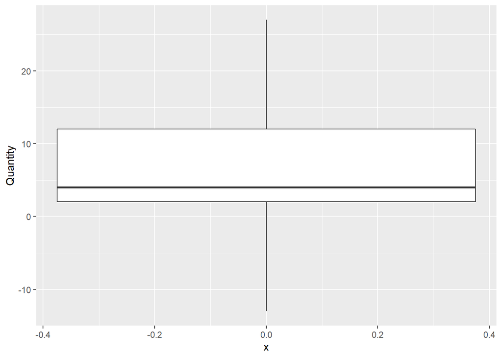

```r
# treiem aquest valors atípics
retail.quantity.nooutliers <-subset(retail.quantity.nooutliers, Quantity >= limits$under)
retail.quantity.nooutliers <-subset(retail.quantity.nooutliers, Quantity <= limits$above)

ggplot(data = retail.quantity.nooutliers,aes(x=0,y=Quantity))+geom_boxplot()
```

```r
total.rows <- nrow(retail.clean);
rows <- nrow(retail.quantity.nooutliers)
paste("Hem eliminat un", 100 - (rows / total.rows) * 100, "% de la mostra")
```

```
## [1] "Hem eliminat un 6.55852950502546 % de la mostra"
```

### 4.4.4 Valors atípics de UnitPrice

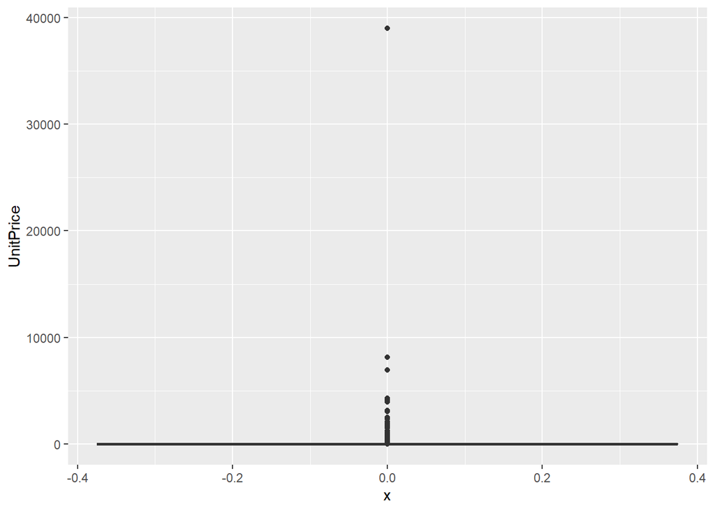

```r
retail.unitprice.nooutliers <- retail.quantity.nooutliers

ggplot(data = retail.unitprice.nooutliers ,aes(x=0,y=UnitPrice))+geom_boxplot()
```

```r
summary(retail.unitprice.nooutliers)
```

```
##    InvoiceNo        StockCode                                  Description
##  576339 :   535   22423  :  1806   REGENCY CAKESTAND 3 TIER          :  1806
##  579196 :   524   85123A :  1724   WHITE HANGING HEART T-LIGHT HOLDER:  1718
##  580727 :   523   85099B :  1365   JUMBO BAG RED RETROSPOT           :  1365
##  578270 :   435   47566  :  1293   PARTY BUNTING                     :  1293
##  573576 :   434   20725  :  1244   LUNCH BAG RED RETROSPOT           :  1244
##  567656 :   419   22720  :  1199   SET OF 3 CAKE TINS PANTRY DESIGN  :  1199
##  (Other):377277   (Other):371516   (Other)                           :371522
##     Quantity                InvoiceDate       UnitPrice          CustomerID
##  Min.   :-13.00   11/14/2011 15:27:   536   Min.   :    0.00   Min.   :12347
##  1st Qu.:  2.00   11/28/2011 15:54:   525   1st Qu.:    1.25   1st Qu.:13975
##  Median :  4.00   12/5/2011 17:17 :   524   Median :    1.95   Median :15187
##  Mean   :  6.82   11/23/2011 13:39:   437   Mean   :    3.60   Mean   :15303
##  3rd Qu.: 12.00   10/31/2011 14:09:   435   3rd Qu.:    3.75   3rd Qu.:16806
##  Max.   : 27.00   9/21/2011 14:40 :   420   Max.   :38970.00   Max.   :18287
##                   (Other)         :377270
##            Country       Cancellation      TotalPrice
##  United Kingdom:340757   Mode :logical   Min.   :-38970.00
##  Germany       :  8959   FALSE:372268    1st Qu.:     3.95
##  France        :  7970   TRUE :7879      Median :    10.20
##  EIRE          :  6602                   Mean   :    13.49
##  Spain         :  2413                   3rd Qu.:    17.40
##  Belgium       :  1992                   Max.   :  8142.75
##  (Other)       : 11454
```

```r
# podem veure els límits de UnitPrice
limits <- outliersLimits(retail.unitprice.nooutliers$UnitPrice)
paste("Límit inferior:", limits$under)
```

```
## [1] "Límit inferior: -2.5"
```

```r
paste("Límit superior:", limits$above)
```

```
## [1] "Límit superior: 7.5"
```

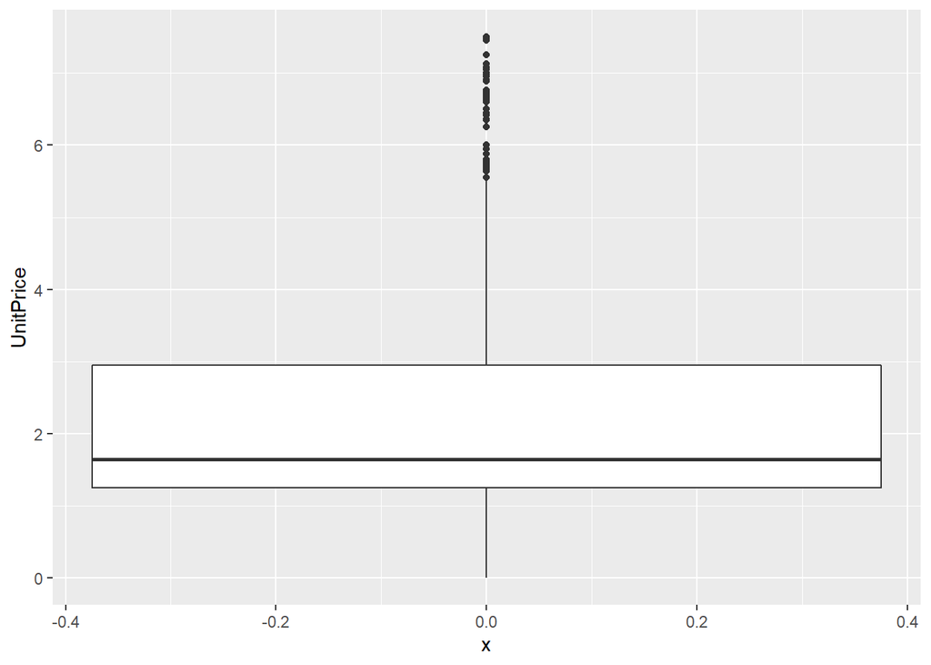

```r
# treiem aquest valors atípics
retail.unitprice.nooutliers <-subset(retail.unitprice.nooutliers, UnitPrice >= limits$under)
retail.unitprice.nooutliers <-subset(retail.unitprice.nooutliers, UnitPrice <= limits$above)

ggplot(data = retail.unitprice.nooutliers,aes(x=0,y=UnitPrice))+geom_boxplot()
```

```r
total.rows <- nrow(retail.quantity.nooutliers);
rows <- nrow(retail.unitprice.nooutliers)
paste("Hem eliminat un", 100 - (rows / total.rows) * 100, "% de la mostra")
```

```
## [1] "Hem eliminat un 9.40530899888728 % de la mostra"
```

```r
paste("Número d'elements final de la mostra:", rows)
```

```
## [1] "Número d'elements final de la mostra: 344393"
```

## 4.5 Tipus d’estudis a realitzar

Prepararem les dades per a fer 2 tipus de clustering a realitzar.

1. Per a fer clustering dels clients.
2. Per a fer clustering dels productes.

## 4.6 Estudi de clusterings de customers

Fem la copia dels dataset primer

```r
# veiem el percentatge de null
retail.customer <- retail.clean
```

Anem a crear un dataset amb un registre per a cada tipus de client. Aquests clients s’identifiquen per el CustomerID.

Ara anem agrupar les transaccions per CustomerId i treurem diferents valors calculats

### 4.6.1 Càlcul de nous valors per customers

Per a realitzar el clustering de customers, muntarem una estructura de dades amb informació de comportament:

1. CustomerId: identificador
2. TotalCost: despesa total del Client
3. NumInvoices: nombre de compres realitzades
4. NumCancellations: nombre de cancel·lacions realitzades
5. NumStocks: nombre de productes diferents que ha comprat el customer
6. Days: dies des de la darrera compra comparat amb la data màxima de compra
7. DiffInvoices: diferència entre compres i cancel·lacions

```r
# trobem el cost total que han fet els Customers
totalCost <- aggregate(cbind(retail.customer$TotalPrice) , by=list(CustomerID=retail.customer$CustomerID), FUN=sum)
totalCost <-setNames(totalCost, c("CustomerID", "TotalCost"))

# trobem el número de factures dels customers (sense cancellacions)
retail.customer.invoices <- subset(retail.customer, Quantity > 0)
numInvoices <- retail.customer.invoices %>% group_by(CustomerID) %>% summarise(NumInvoices = n_distinct(InvoiceNo))

# trobem el número de cancelacions de invoices dels customers
retail.customer.cancellations <- subset(retail.customer, Quantity < 0)
numCancellations <- retail.customer.cancellations %>% group_by(CustomerID) %>% summarise(NumCancellations = n_distinct(InvoiceNo))

# trobem el número de productes diferents
numStocks <- retail.customer.invoices %>% group_by(CustomerID) %>% summarise(NumStocks = n_distinct(StockCode))

# trobem els dies des de la data màxima de compra (quan fà que no compren des de la data màxima)
## primer la data màxima total
retail.customer$InvoiceDateTime  <- as.POSIXct(retail.customer$InvoiceDate, format='%m/%d/%Y %H:%M')
maxDate <- max(retail.customer$InvoiceDateTime)
## segon la data màxima de cada customer
lastDateCustomer <- retail.customer %>% group_by(CustomerID) %>% summarise(LastDate = max(InvoiceDateTime))
lastDateCustomer$Diff <- round(as.numeric(maxDate - lastDateCustomer$LastDate, units = "days"), 1)
lastDateCustomer$LastDate <- NULL
lastDateCustomer <-setNames(lastDateCustomer, c("CustomerID", "Days"))

# fem merge amb outter join per a tenir tots els registres i als nulls els hi posem valor 0
retail.customer.final <- merge(numInvoices,numCancellations,by="CustomerID", all = TRUE)
retail.customer.final[is.na(retail.customer.final)] <- 0
retail.customer.final <- merge(retail.customer.final,totalCost,by="CustomerID", all = TRUE)
retail.customer.final <- merge(retail.customer.final,numStocks,by="CustomerID", all = TRUE)
retail.customer.final <- merge(retail.customer.final,lastDateCustomer,by="CustomerID", all = TRUE)
retail.customer.final$DiffInvoices <-  retail.customer.final$NumInvoices - retail.customer.final$NumCancellations
retail.customer.final[is.na(retail.customer.final)] <- 0

summary(retail.customer.final)
```

```
##    CustomerID     NumInvoices     NumCancellations    TotalCost
##  Min.   :12346   Min.   :  0.00   Min.   : 0.0000   Min.   : -4287.6
##  1st Qu.:13813   1st Qu.:  1.00   1st Qu.: 0.0000   1st Qu.:   293.4
##  Median :15300   Median :  2.00   Median : 0.0000   Median :   648.1
##  Mean   :15300   Mean   :  4.24   Mean   : 0.8358   Mean   :  1898.5
##  3rd Qu.:16778   3rd Qu.:  5.00   3rd Qu.: 1.0000   3rd Qu.:  1611.7
##  Max.   :18287   Max.   :210.00   Max.   :47.0000   Max.   :279489.0
##    NumStocks            Days         DiffInvoices
##  Min.   :   0.00   Min.   :  0.00   Min.   : -6.000
##  1st Qu.:  15.00   1st Qu.: 16.10   1st Qu.:  1.000
##  Median :  35.00   Median : 49.90   Median :  2.000
##  Mean   :  61.03   Mean   : 91.59   Mean   :  3.404
##  3rd Qu.:  77.00   3rd Qu.:142.93   3rd Qu.:  4.000
##  Max.   :1787.00   Max.   :373.10   Max.   :196.000
```

```r
# finalment treiem la columna de CustomerId per a fer el clustering
retail.customer.final <- retail.customer.final[,2:7]
```

Ja tenim montat el model de comportament de compra del customer. Per a fer la prova treurem la columna CustomerId.

## 4.7 Estudi de clustering de productes

Per a realitzar el clustering de productes, muntarem una estructura de dades amb la següent informació:

- StockCode: serà l’identificador del producte
- Description: la descripció
- UnitPrice: preu unitari
- TotalStockUnits: unitats totals comprades
- TotalStockPrice: preu total gastat
- LastDate: darrera compra del producte

Fem la copia dels dataset primer

```r
# veiem el percentatge de null
retail.product <- retail.clean
```

```r
head(retail.product)
```

```
##   InvoiceNo StockCode                         Description Quantity
## 1    536365    85123A  WHITE HANGING HEART T-LIGHT HOLDER        6
## 2    536365     71053                 WHITE METAL LANTERN        6
## 3    536365    84406B      CREAM CUPID HEARTS COAT HANGER        8
## 4    536365    84029G KNITTED UNION FLAG HOT WATER BOTTLE        6
## 5    536365    84029E      RED WOOLLY HOTTIE WHITE HEART.        6
## 6    536365     22752        SET 7 BABUSHKA NESTING BOXES        2
##      InvoiceDate UnitPrice CustomerID        Country Cancellation TotalPrice
## 1 12/1/2010 8:26      2.55      17850 United Kingdom        FALSE      15.30
## 2 12/1/2010 8:26      3.39      17850 United Kingdom        FALSE      20.34
## 3 12/1/2010 8:26      2.75      17850 United Kingdom        FALSE      22.00
## 4 12/1/2010 8:26      3.39      17850 United Kingdom        FALSE      20.34
## 5 12/1/2010 8:26      3.39      17850 United Kingdom        FALSE      20.34
## 6 12/1/2010 8:26      7.65      17850 United Kingdom        FALSE      15.30
```

```r
# generem les unitats totals venudes de cada producte
totalStockUnits <- retail.product %>% group_by(StockCode) %>% summarise(TotalStockUnits = sum(Quantity))
totalStockUnits <-setNames(totalStockUnits, c("StockCode", "TotalStockUnits"))

# generem el preu total venut de cada producte
totalStockPrice <- retail.product %>% group_by(StockCode) %>% summarise(TotalStockPrice = sum(TotalPrice))
totalStockPrice <-setNames(totalStockPrice, c("StockCode", "TotalStockPrice"))

# per unit price agafarem el valor mitjà
unitPrice <- retail.product %>% group_by(StockCode) %>% summarise(UnitPrice = round(mean(UnitPrice), 2))
unitPrice <-setNames(unitPrice, c("StockCode", "UnitPrice"))

# trobem els dia des de la data compra d'un producte (quan fà que no es compra un producte)
# primer necessitem la data màxima total
retail.product$InvoiceDateTime  <- as.POSIXct(retail.product$InvoiceDate, format='%m/%d/%Y %H:%M')
maxDate <- max(retail.product$InvoiceDateTime)
## segon la data màxima de cada producte
lastDateProduct <- retail.product %>% group_by(StockCode) %>% summarise(LastDate = max(InvoiceDateTime))
lastDateProduct$Diff <- round(as.numeric(maxDate - lastDateProduct$LastDate, units = "days"), 1)
lastDateProduct$LastDate <- NULL
lastDateProduct <-setNames(lastDateProduct, c("StockCode", "Days"))

#  montem el dataset final
retail.product.final <- unique(retail.product[,-c(1,4:11)])

retail.product.final <- merge(retail.product.final,unitPrice,by="StockCode", all = TRUE)
retail.product.final <- merge(retail.product.final,totalStockUnits,by="StockCode", all = TRUE)
# retail.product.final <- merge(retail.product.final,totalStockPrice,by="StockCode", all = TRUE)
retail.product.final <- merge(retail.product.final,lastDateProduct,by="StockCode", all = TRUE)
retail.product.final$TotalStockPrice <- retail.product.final$TotalStockUnits * retail.product.final$UnitPrice

summary(retail.product.final)
```

```
##    StockCode                             Description     UnitPrice
##  23196  :   4   METAL SIGN,CUPCAKE SINGLE HOOK :   3   Min.   :  0.000
##  23236  :   4   COLOURING PENCILS BROWN TUBE   :   2   1st Qu.:  1.010
##  17107D :   3   COLUMBIAN CANDLE RECTANGLE     :   2   Median :  1.950
##  22776  :   3   COLUMBIAN CANDLE ROUND         :   2   Mean   :  3.818
##  22937  :   3   EAU DE NILE JEWELLED PHOTOFRAME:   2   3rd Qu.:  3.880
##  23126  :   3   FRENCH FLORAL CUSHION COVER    :   2   Max.   :744.150
##  (Other):3896   (Other)                        :3903
##  TotalStockUnits        Days        TotalStockPrice
##  Min.   :-1460.0   Min.   :  0.00   Min.   : -86541.1
##  1st Qu.:   67.0   1st Qu.:  0.90   1st Qu.:    142.7
##  Median :  414.5   Median :  3.10   Median :    750.7
##  Mean   : 1395.3   Mean   : 46.06   Mean   :   2861.7
##  3rd Qu.: 1437.0   3rd Qu.: 32.02   3rd Qu.:   2373.4
##  Max.   :53215.0   Max.   :373.10   Max.   :1064825.1
##
```

```r
# Treiem el StockCode i Description per a fer el clustering
retail.product.final <- retail.product.final[,3:6]
```

Ja tenim una part del model generat per a cerca de clusters de productes.

## 4.8 Estudi PCA (Principal Component Analysis)

Amb l’estudi PCA volem reduir la dimensionalitat del dataset.

### 4.8.1 Estudi PCA de Product

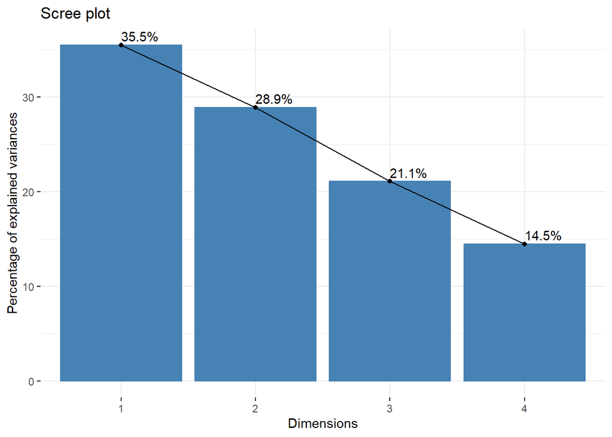

```r
# agafem les variables numèriques amb les que farem l'estudi de clustering
pca <- retail.product.final[,1:4]
# executem l'estudi PCA
pca <- prcomp(pca, scale. = TRUE)

# la funció mostra la variança de cada component
fviz_eig(pca, choice = c("variance"), addlabels = TRUE)
```

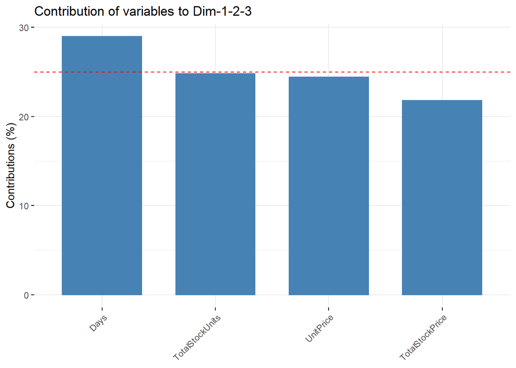

```r
# relació entre les dimensions i atributs.
fviz_contrib(pca, choice = "var", axes = 1:3)
```

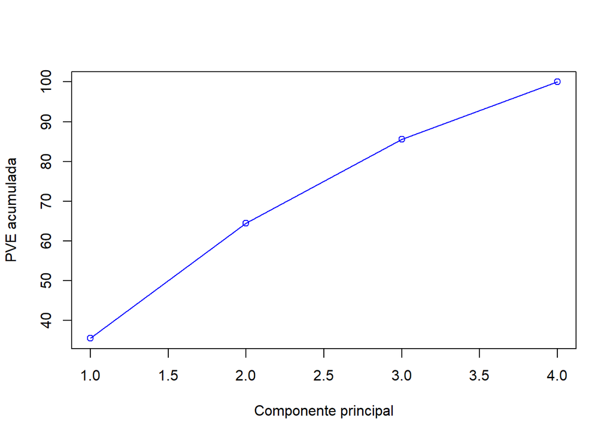

```r
# pve acumulada
PVE <- 100*pca$sdev^2/sum(pca$sdev^2)

plot(cumsum(PVE), type = "o",
     ylab = "PVE acumulada",
     xlab = "Componente principal",
     col = "blue")
```

El que ens està dient l’estudi de variança explicada és que totes les dimensions tenen força pes encara que hi hagi algunes que en tinguin molt més. No obviarem cap d’elles.

### 4.8.2 Estudi PCA de Consumer

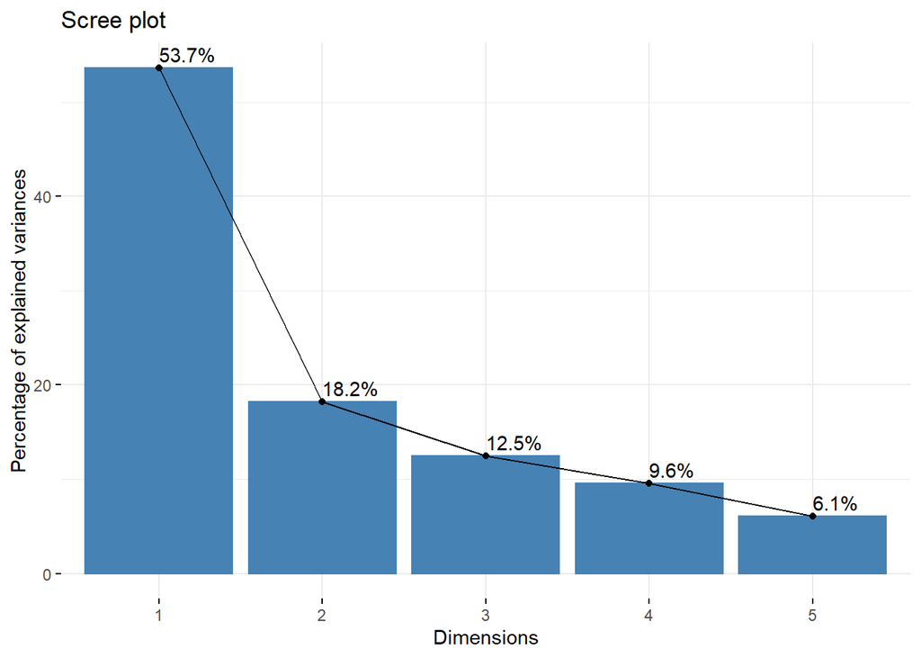

```r
# agafem les variables numèriques amb les que farem l'estudi de clustering
pca <- retail.customer.final[,2:6]

# executem l'estudi PCA
pca <- prcomp(pca, scale. = TRUE)

# la funció mostra la variança de cada component
fviz_eig(pca, choice = c("variance", "eigenvalue"), addlabels = TRUE)
```

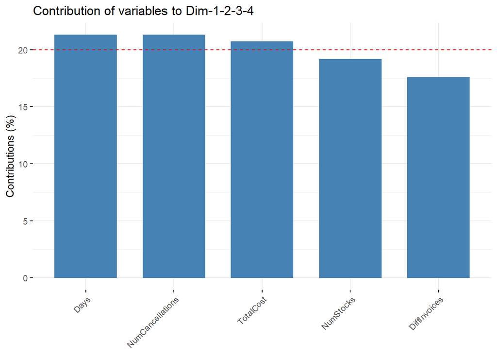

```r
# relació entre les dimensions i contribució
fviz_contrib(pca, choice = "var", axes = 1:4)
```

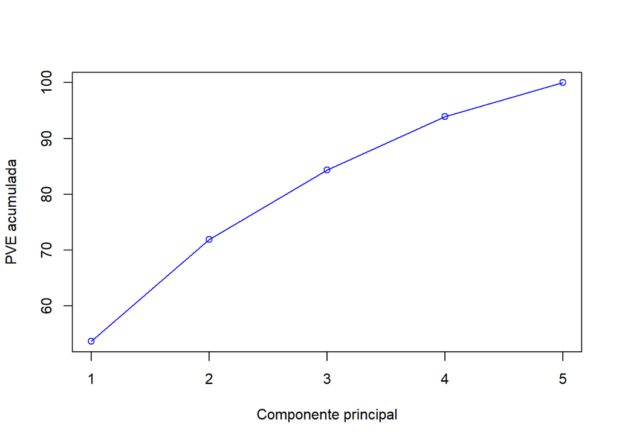

```r
# pve acumulada
PVE <- 100*pca$sdev^2/sum(pca$sdev^2)

plot(cumsum(PVE), type = "o",
     ylab = "PVE acumulada",
     xlab = "Componente principal",
     col = "blue")
```

En la primera gràfica veiem la contribució de cada dimensió als conjunts de dades. Aquí hi ha més diferència entre la primera i la resta. Tenim una dimensió que ens dóna molta informació i les altres molt menys.

En la segona gràfica veiem que amb 4 dimensions “expliquem” gran part dels atributs.

En la gràfica de proporció de variança a acumulada, una mica el mateix, amb 4 components tenim més del 90% del model explicat.

Tampoc esborrarem cap atribut.

# 5 Associació

## 5.1 Joc de dades

L’estudi d’associació el faré amb els mateix datase de [venta online](http://archive.ics.uci.edu/ml/datasets/Online+Retail)

Per a realitzar l’estudi d’associations el que farem serà és agrupar cada InvoiceId com una transacció única. Veient quins articles tenim en les diferents transaccions podrem comprovar tendències de compra. A partir d’aquest estudi podrien fer campanyes d’ads (recordem que és un dataset de venta online), i mostrar anuncis oportuns quan l’usuari està navegant pel site i sabem quins productes ja ha comprat.

## 5.2 Anàlisi exploratori

```r
summary(retail)
```

```
##    InvoiceNo        StockCode                                  Description
##  573585 :  1114   85123A :  2313   WHITE HANGING HEART T-LIGHT HOLDER:  2369
##  581219 :   749   22423  :  2203   REGENCY CAKESTAND 3 TIER          :  2200
##  581492 :   731   85099B :  2159   JUMBO BAG RED RETROSPOT           :  2159
##  580729 :   721   47566  :  1727   PARTY BUNTING                     :  1727
##  558475 :   705   20725  :  1639   LUNCH BAG RED RETROSPOT           :  1638
##  579777 :   687   84879  :  1502   ASSORTED COLOUR BIRD ORNAMENT     :  1501
##  (Other):537202   (Other):530366   (Other)                           :530315
##     Quantity                   InvoiceDate       UnitPrice
##  Min.   :-80995.00   10/31/2011 14:41:  1114   Min.   :-11062.06
##  1st Qu.:     1.00   12/8/2011 9:28  :   749   1st Qu.:     1.25
##  Median :     3.00   12/9/2011 10:03 :   731   Median :     2.08
##  Mean   :     9.55   12/5/2011 17:24 :   721   Mean   :     4.61
##  3rd Qu.:    10.00   6/29/2011 15:58 :   705   3rd Qu.:     4.13
##  Max.   : 80995.00   11/30/2011 15:13:   687   Max.   : 38970.00
##                      (Other)         :537202
##    CustomerID               Country       Cancellation      TotalPrice
##  Min.   :12346    United Kingdom:495478   Mode :logical   Min.   :-168469.60
##  1st Qu.:13953    Germany       :  9495   FALSE:532621    1st Qu.:      3.40
##  Median :15152    France        :  8557   TRUE :9288      Median :      9.75
##  Mean   :15288    EIRE          :  8196                   Mean   :     17.99
##  3rd Qu.:16791    Spain         :  2533                   3rd Qu.:     17.40
##  Max.   :18287    Netherlands   :  2371                   Max.   : 168469.60
##  NA's   :135080   (Other)       : 15279
```

L’hem fet en el apartat de Clustering.

## 5.3 Tasques de neteja

### 5.3.1 Camps null (missing values)

```r
retail.association <- retail
total.num <- nrow(retail.association)
retail.association <- subset(retail.association, !is.na(CustomerID))
cat("Amb els NA hem eliminat un:", 100 - round(nrow(retail.association) / total.num * 100, 2), "de registres.")
```

```
## Amb els NA hem eliminat un: 24.93 de registres.
```

### 5.3.2 Eliminem devolucions

No volem les devolucions per aquest estudi. No ens aporta res.

```r
total.num <- nrow(retail.association)
retail.association <- subset(retail.association, !startsWith(as.character(retail.association$InvoiceNo), 'C'))
cat("Amb les devolucions hem eliminat un:", 100 - round(nrow(retail.association) / total.num * 100, 2), "de registres.")
```

```
## Amb les devolucions hem eliminat un: 2.19 de registres.
```

### 5.3.3 Valors atípics extrems (outliers)

Farem servir la funció del apartat 1 per a trobar els límits

### 5.3.4 Valors atípics a Quantity

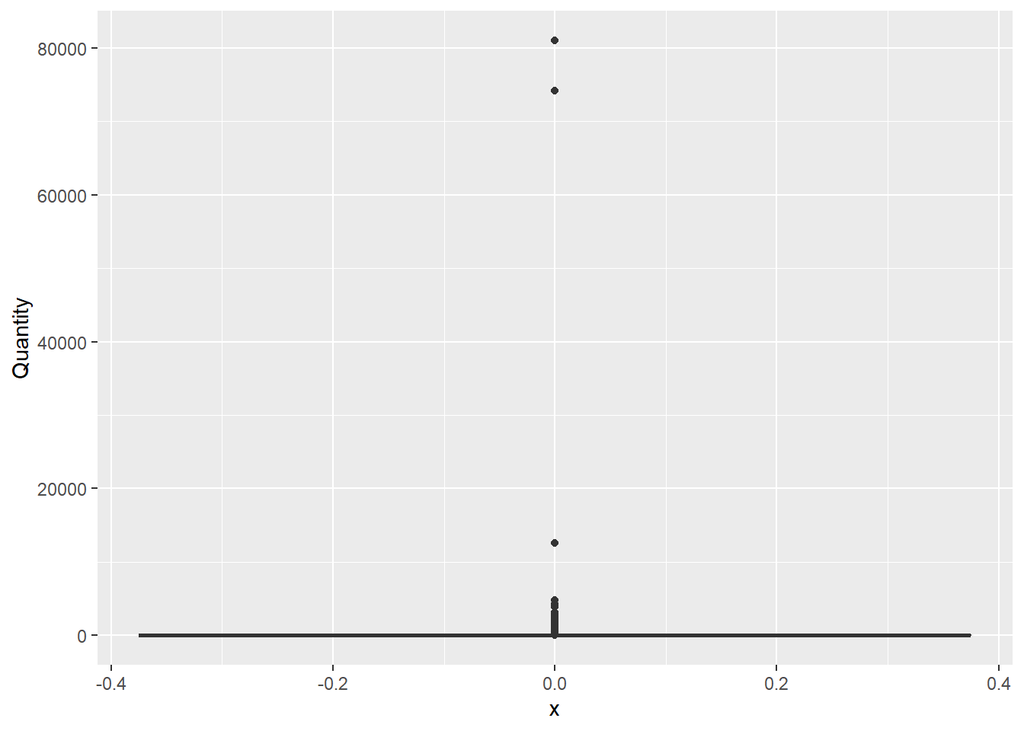

```r
retail.quantity.nooutliers <- retail.association

ggplot(data = retail.quantity.nooutliers ,aes(x=0,y=Quantity))+geom_boxplot()
```

```r
summary(retail.quantity.nooutliers)
```

```
##    InvoiceNo        StockCode                                  Description
##  576339 :   542   85123A :  2035   WHITE HANGING HEART T-LIGHT HOLDER:  2028
##  579196 :   533   22423  :  1724   REGENCY CAKESTAND 3 TIER          :  1724
##  580727 :   529   85099B :  1618   JUMBO BAG RED RETROSPOT           :  1618
##  578270 :   442   84879  :  1408   ASSORTED COLOUR BIRD ORNAMENT     :  1408
##  573576 :   435   47566  :  1397   PARTY BUNTING                     :  1397
##  567656 :   421   20725  :  1317   LUNCH BAG RED RETROSPOT           :  1316
##  (Other):395022   (Other):388425   (Other)                           :388433
##     Quantity                  InvoiceDate       UnitPrice
##  Min.   :    1.00   11/14/2011 15:27:   542   Min.   :   0.000
##  1st Qu.:    2.00   11/28/2011 15:54:   533   1st Qu.:   1.250
##  Median :    6.00   12/5/2011 17:17 :   529   Median :   1.950
##  Mean   :   13.02   11/23/2011 13:39:   443   Mean   :   3.116
##  3rd Qu.:   12.00   10/31/2011 14:09:   435   3rd Qu.:   3.750
##  Max.   :80995.00   9/21/2011 14:40 :   421   Max.   :8142.750
##                     (Other)         :395021
##    CustomerID              Country       Cancellation      TotalPrice
##  Min.   :12346   United Kingdom:354345   Mode :logical   Min.   :     0.00
##  1st Qu.:13969   Germany       :  9042   FALSE:397924    1st Qu.:     4.68
##  Median :15159   France        :  8342                   Median :    11.80
##  Mean   :15294   EIRE          :  7238                   Mean   :    22.39
##  3rd Qu.:16795   Spain         :  2485                   3rd Qu.:    19.80
##  Max.   :18287   Netherlands   :  2363                   Max.   :168469.60
##                  (Other)       : 14109
```

```r
# podem veure els límits de Quantity
limits <- outliersLimits(retail.quantity.nooutliers$Quantity)
paste("Límit inferior:", limits$under)
```

```
## [1] "Límit inferior: -13"
```

```r
paste("Límit superior:", limits$above)
```

```
## [1] "Límit superior: 27"
```

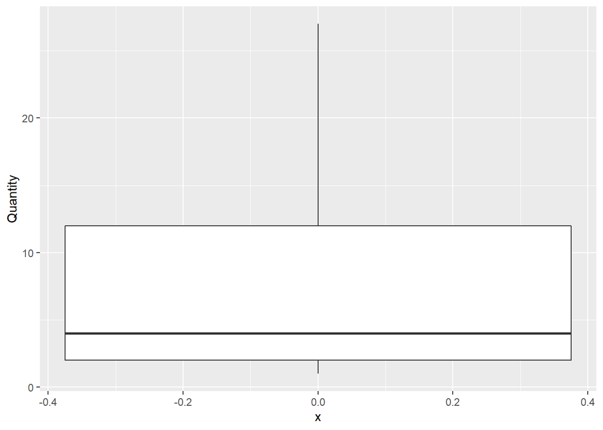

```r
# treiem aquest valors atípics
retail.quantity.nooutliers <-subset(retail.quantity.nooutliers, Quantity >= limits$under)
retail.quantity.nooutliers <-subset(retail.quantity.nooutliers, Quantity <= limits$above)

ggplot(data = retail.quantity.nooutliers,aes(x=0,y=Quantity))+geom_boxplot()
```

```r
total.rows <- nrow(retail.association);
rows <- nrow(retail.quantity.nooutliers)
paste("Hem eliminat un", 100 - (rows / total.rows) * 100, "% de la mostra")
```

```
## [1] "Hem eliminat un 6.44746232949005 % de la mostra"
```

### 5.3.5 Valors atípics de UnitPrice

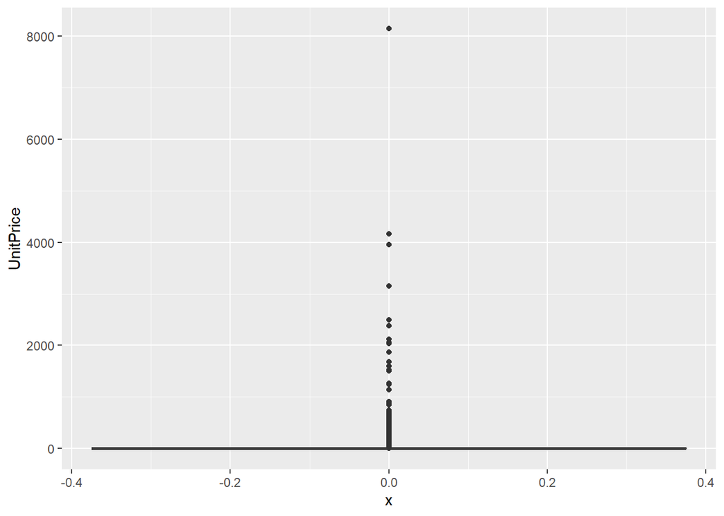

```r
retail.unitprice.nooutliers <- retail.quantity.nooutliers

ggplot(data = retail.unitprice.nooutliers ,aes(x=0,y=UnitPrice))+geom_boxplot()
```

```r
summary(retail.unitprice.nooutliers)
```

```
##    InvoiceNo        StockCode                                  Description
##  576339 :   535   85123A :  1686   WHITE HANGING HEART T-LIGHT HOLDER:  1680
##  579196 :   524   22423  :  1635   REGENCY CAKESTAND 3 TIER          :  1635
##  580727 :   523   85099B :  1329   JUMBO BAG RED RETROSPOT           :  1329
##  578270 :   435   47566  :  1278   PARTY BUNTING                     :  1278
##  573576 :   434   20725  :  1207   LUNCH BAG RED RETROSPOT           :  1207
##  567656 :   419   84879  :  1159   ASSORTED COLOUR BIRD ORNAMENT     :  1159
##  (Other):369398   (Other):363974   (Other)                           :363980
##     Quantity               InvoiceDate       UnitPrice          CustomerID
##  Min.   : 1.00   11/14/2011 15:27:   535   Min.   :   0.000   Min.   :12347
##  1st Qu.: 2.00   11/28/2011 15:54:   524   1st Qu.:   1.250   1st Qu.:13985
##  Median : 4.00   12/5/2011 17:17 :   523   Median :   1.950   Median :15194
##  Mean   : 7.03   11/23/2011 13:39:   436   Mean   :   3.228   Mean   :15309
##  3rd Qu.:12.00   10/31/2011 14:09:   434   3rd Qu.:   3.750   3rd Qu.:16813
##  Max.   :27.00   9/21/2011 14:40 :   419   Max.   :8142.750   Max.   :18287
##                  (Other)         :369397
##            Country       Cancellation      TotalPrice
##  United Kingdom:334095   Mode :logical   Min.   :   0.00
##  Germany       :  8519   FALSE:372268    1st Qu.:   4.20
##  France        :  7843                   Median :  10.20
##  EIRE          :  6400                   Mean   :  14.37
##  Spain         :  2379                   3rd Qu.:  17.70
##  Belgium       :  1954                   Max.   :8142.75
##  (Other)       : 11078
```

```r
# podem veure els límits de UnitPrice
limits <- outliersLimits(retail.unitprice.nooutliers$UnitPrice)
paste("Límit inferior:", limits$under)
```

```
## [1] "Límit inferior: -2.5"
```

```r
paste("Límit superior:", limits$above)
```

```
## [1] "Límit superior: 7.5"
```

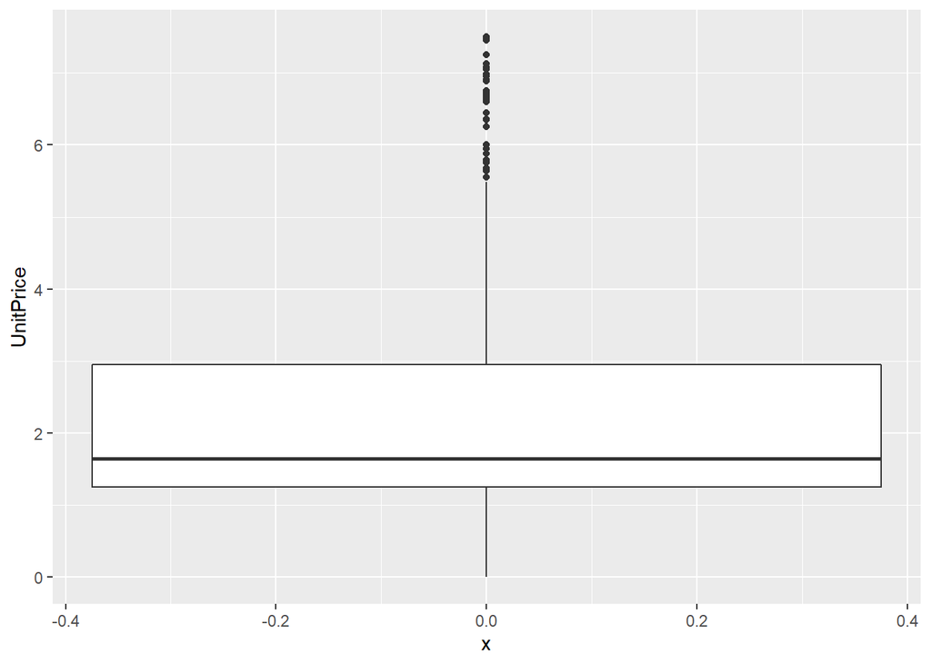

```r
# treiem aquest valors atípics
retail.unitprice.nooutliers <-subset(retail.unitprice.nooutliers, UnitPrice >= limits$under)
retail.unitprice.nooutliers <-subset(retail.unitprice.nooutliers, UnitPrice <= limits$above)

ggplot(data = retail.unitprice.nooutliers,aes(x=0,y=UnitPrice))+geom_boxplot()
```

```r
total.rows <- nrow(retail.quantity.nooutliers);
rows <- nrow(retail.unitprice.nooutliers)
paste("Hem eliminat un", 100 - (rows / total.rows) * 100, "% de la mostra")
```

```
## [1] "Hem eliminat un 9.15630674675234 % de la mostra"
```

```r
paste("Número d'elements final de la mostra:", rows)
```

```
## [1] "Número d'elements final de la mostra: 338182"
```

Realment hem fet molta neteja de la mostra. Ens podríem haver quedat amb més dades i no filtrar tant per UnitPrice sobretot perquè estem traient força elements (productes) per a fer l’anàlisi. De totes maneres, amb la mostra que ens ha quedat podem fer perfectament l’estudi per a predir comportament de compra amb dades més coherents i el support amb valors extrems seria força baix.

**En la segona práctica farem l’estudi d’associació amb i sense els elements atípics per a comparar resultats.**

## 5.4 Estudi de les dades resultants

Com hem comentat farem servir cada una de les Invoices com a transaccions. Cada transacció conté un nombre de productes.

```r
retail.association <- retail.unitprice.nooutliers
summary(retail.association)
```

```
##    InvoiceNo        StockCode                                  Description
##  576339 :   460   85123A :  1686   WHITE HANGING HEART T-LIGHT HOLDER:  1680
##  579196 :   450   85099B :  1329   JUMBO BAG RED RETROSPOT           :  1329
##  580727 :   442   47566  :  1275   PARTY BUNTING                     :  1275
##  573576 :   384   20725  :  1207   LUNCH BAG RED RETROSPOT           :  1207
##  567656 :   370   84879  :  1159   ASSORTED COLOUR BIRD ORNAMENT     :  1159
##  578270 :   369   22720  :  1120   SET OF 3 CAKE TINS PANTRY DESIGN  :  1120
##  (Other):335707   (Other):330406   (Other)                           :330412
##     Quantity                InvoiceDate       UnitPrice       CustomerID
##  Min.   : 1.000   11/14/2011 15:27:   460   Min.   :0.000   Min.   :12347
##  1st Qu.: 2.000   11/28/2011 15:54:   450   1st Qu.:1.250   1st Qu.:13994
##  Median : 6.000   12/5/2011 17:17 :   442   Median :1.650   Median :15245
##  Mean   : 7.477   10/31/2011 14:09:   384   Mean   :2.192   Mean   :15326
##  3rd Qu.:12.000   11/23/2011 13:39:   370   3rd Qu.:2.950   3rd Qu.:16818
##  Max.   :27.000   9/21/2011 14:40 :   370   Max.   :7.500   Max.   :18287
##                   (Other)         :335706
##            Country       Cancellation      TotalPrice
##  United Kingdom:305151   Mode :logical   Min.   :  0.00
##  Germany       :  7465   FALSE:338182    1st Qu.:  3.80
##  France        :  6905                   Median : 10.08
##  EIRE          :  5451                   Mean   : 12.77
##  Spain         :  2046                   3rd Qu.: 17.40
##  Belgium       :  1660                   Max.   :178.80
##  (Other)       :  9504
```

```r
invoices <- retail.association[,"InvoiceNo"]
paste("El número total de transaccions és de: ", n_distinct(invoices))
```

```
## [1] "El número total de transaccions és de:  16835"
```

## 5.5 Obtenció de transaccions

```r
transations <- split(x=retail.association[,"Description"],f=retail.association$InvoiceNo)

# trasformem el data com a transactions. Cada transacció es una compra (InvioceNo) i els productes que ha comprat
transations <- as(transations,"transactions")
```

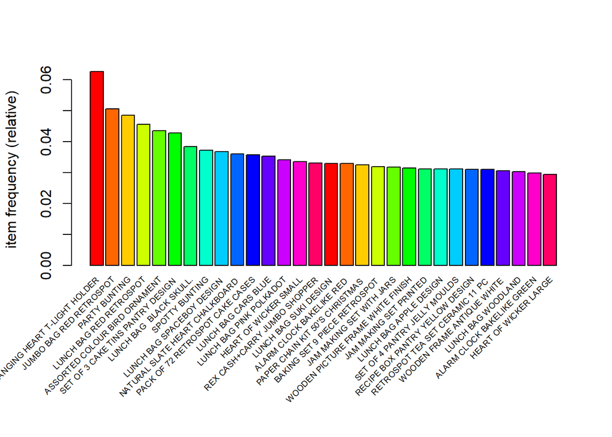

```r
itemFrequencyPlot(transations, support = 0.02, cex.names = .6, col = rainbow(15), topN=30)
```

Aquest son els elements més utilitzats. Ja hem generat les transaccions i ja està preparat per a estudiar les associacions.